# Arab Region Employees

### 1.0 Problem:

There is a lack of data regarding the factors that influence the salaries of Arab employees. This knowledge gap makes it difficult for organizations and authorities to make well-informed choices about future employee planning, and providing fair salaries across the Arab world. To address this issue, we aim to use the Arab Employee dataset, which will provide important data on Arab professionals’ qualifications, locations, and years of experience. We can help organizations and authorities make better decisions by getting this data, thereby encouraging fair salaries practices and enhancing people management strategies in the Arab area.

### 2.0 Data Mining Tasks:

Data mining is essential for predicting the likelihood of achieving fair salary classifications and employing clustering techniques. By utilizing data mining algorithms on a vast dataset that encompasses the qualifications, geographic locations, and years of experience of diverse professionals, we can extract valuable insights.

#### Here are three specific goals we have for this dataset:

#### 2.1 Classification Goal:

We want to group employees into different categories based on their qualifications, country location, and experience. By doing this, we can see patterns and trends among different groups. This will help us understand if there are differences in pay based on qualifications and experience, and it will help us identify talented individuals. With this information, we can develop strategies to support career growth and make sure people are being paid fairly.

#### 2.2 Clustering Goal:

We want to group similar data points so we grouped employees with similar salaries together. By doing this, will help in uncovering hidden patterns and structures within the data, making it easier to understand the inherent relationships between different employees’ info. It also makes it feasible to divide our enormous dataset into smaller, easier-to-understand subsets. This can make analyzing complicated datasets easier.

#### 2.3 Defect Prediction Goal:

We want to use machine learning and statistical techniques to create models that can predict any issues or anomalies with employee salaries. This could include things like unfair pay practices, wage gaps, or differences based on qualifications or experience. By catching these problems early, we can fix them and make sure everyone is being treated fairly. This analysis will help us improve compensation policies and make better decisions about managing talent.

#### By achieving these goals, we can:

Understand how salaries are distributed among different employee groups. Identify any biases or unfairness in pay based on qualifications, experience, or location. Develop strategies for hiring, developing, and keeping talented employees. Make sure pay practices are fair and transparent. Catch and fix salary-related issues before they become bigger problems. Plan for the future workforce and allocate resources effectively. Make better decisions about pay and talent management in the Arab region. Overall, collecting the Arab Employee dataset with information about salary, qualifications, location, and experience is really important. It will help us analyze the data and make fair decisions that create a good working environment for Arab professionals.

### 3.0 Data

### 3.1 Source of the dataset:

Kaggle

### 3.2 link of the dataset:

https://www.kaggle.com/datasets/qusaybtoush1990/employes <sup>[1]</sup>

### 3.3 General Information about Employees dataset:

Our dataset contains 10 attributes, and 740 objects (See Table 1). Furthermore, the class label for our dataset is Salary.

##### Table 1: General Information about the attributes for Employees dataset.

[output not shown]

#### 3.4 Sample of Employees dataset

```r
View(Employees)
```

#### 3.5 Number of column and rows

```r
dim(Employees)
```

```
[1] 740  10
```

#### 3.6 statiscal summarise -Nominal-

```r
summary(Employees$Education)
```

```
   Length     Class      Mode
      740 character character
```

```r
summary(Employees$Department)
```

```
   Length     Class      Mode
      740 character character
```

```r
summary(Employees$'Job Status')
```

```
   Length     Class      Mode
      740 character character
```

```r
summary(Employees$Location)
```

```
   Length     Class      Mode
      740 character character
```

#### 3.7 statiscal summarise -Numerical-

```r
summary(Employees$Years)
```

```
   Min. 1st Qu.  Median    Mean 3rd Qu.    Max.    NA's
  1.000   2.000   4.000   4.341   6.000   9.000      72
```

```r
summary(Employees$Salary)
```

```
   Min. 1st Qu.  Median    Mean 3rd Qu.    Max.
  650.0   970.8  1580.5  1517.6  2074.0  2500.0
```

```r
summary(Employees$'Job Rate')
```

```
   Min. 1st Qu.  Median    Mean 3rd Qu.    Max.
  1.000   3.000   5.000   5.292   8.000  13.000
```

```r
summary(Employees$Permissions)
```

```
   Min. 1st Qu.  Median    Mean 3rd Qu.    Max.
  1.000   4.000   7.000   7.435  11.000  14.000
```

Description of summary: This is the summary of all data set including Nominal and Numerical Data.

#### 3.8 Code for variance

```r
var(Employees$Salary)
```

```
[1] 353862
```

### 3.9 Graphs

As we know, graphs are great tools for analyzing patterns and relationships in data because they provide a visual way to explore and evaluate data. So, in this section, we discussed some plots to have a full review of our data.

#### 3.9.1 Box plot for salary and years

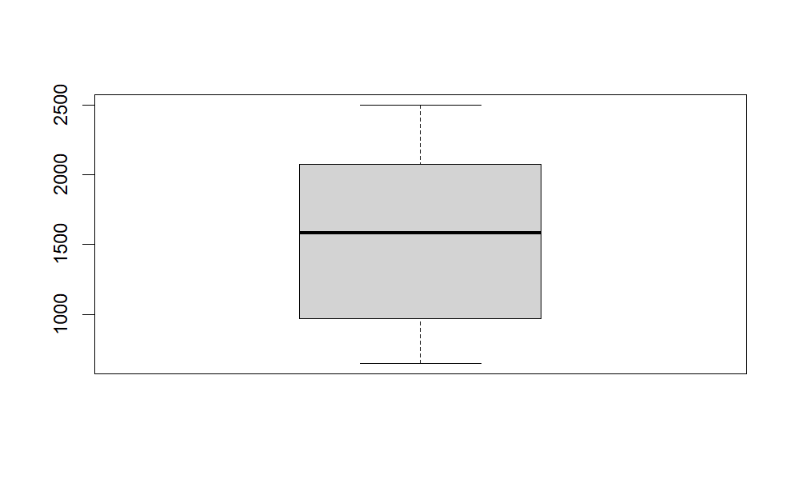

```r
boxplot(Employees$Salary)
```

Description for Salary boxplot: The Salary boxplot illustrates that the salaries are evenly distributed around the middle point, indicating a relatively balanced salary distribution.

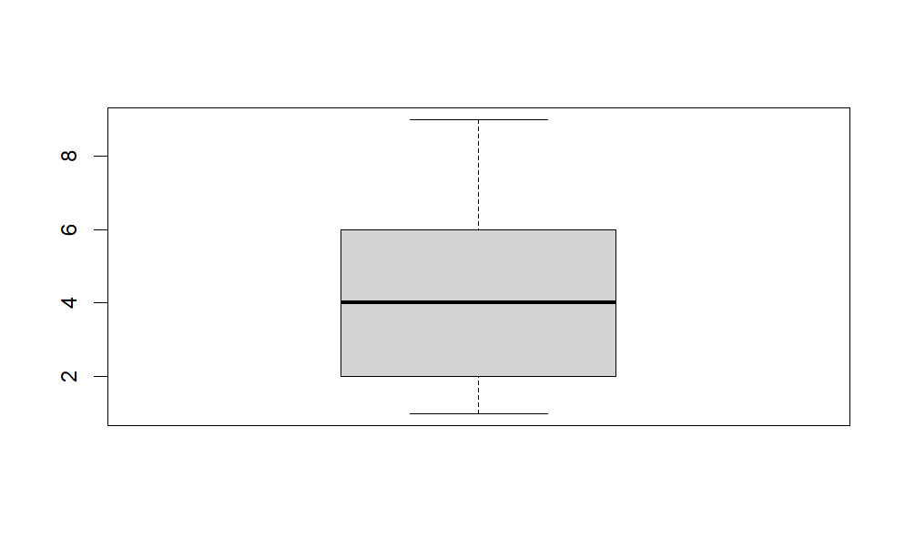

```r
boxplot(Employees$Years)
```

Description for Years boxplot: The Years of Work boxplot illustrates how the values in the dataset have relatively balanced around the median value of 4.

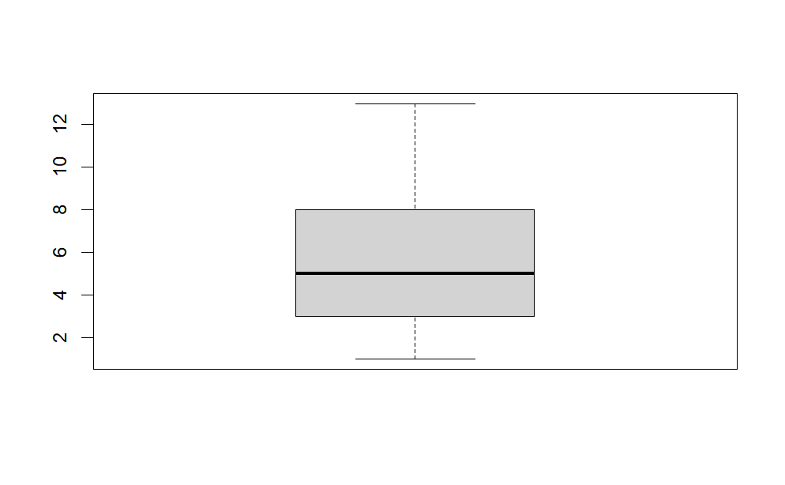

```r
boxplot(Employees$'Job Rate')
```

Description for Job rate boxplot: The Job rate boxplot is relatively balanced around the median value of 5. In a more comprehensive analysis, there is a spread in the job rates above 50% of the dataset.

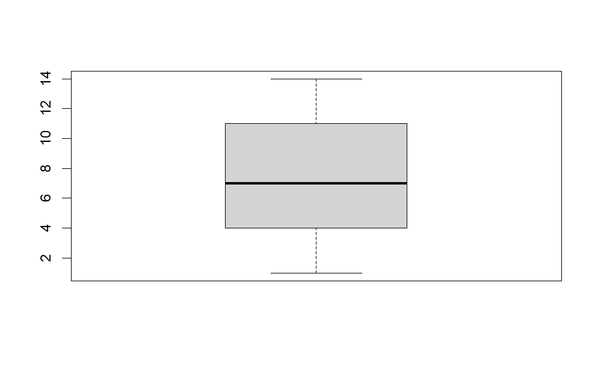

```r
boxplot(Employees$Permissions)
```

Description for Permissions boxplot: The Permissions boxplot reveals several important insights about the distribution of Permissions. It illustrates that the values of the attribute are almost balanced near to the median.

#### 3.9.2 Histogram for permission

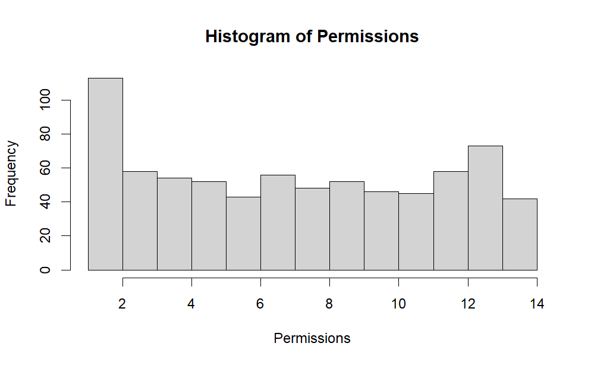

```r
Permissions <- Employees$Permissions
hist(Permissions)
```

#### 3.9.3 Bar Chart for Salary

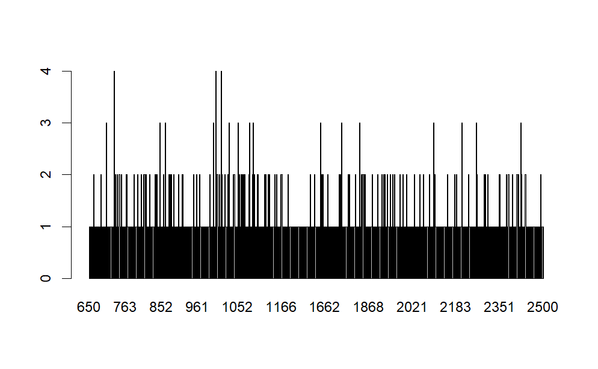

```r
#Bar Chart
Employees$Salary %>% table() %>% barplot()
```

Description for Bar Chart for Salary: The frequency of Salary for the employees in the dataset is represented by the Bar chart. Since the bar chart is made for salary, the frequency of each value mostly appears ones. For best representation; it will be better to do discretisation before.

#### 3.9.4 pie chart for Education

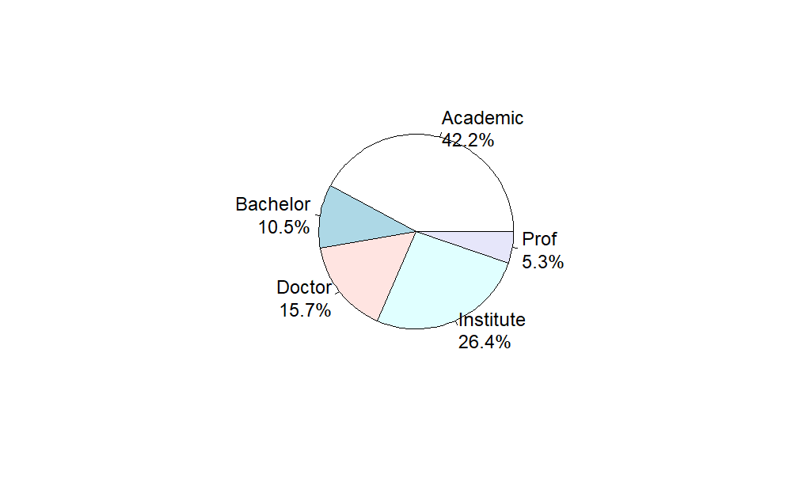

```r
tab <- Employees$Education %>% table()
precentages <- tab %>% prop.table() %>% round(3) * 100
txt <- paste0(names(tab), '\n', precentages, '%')
pie(tab, labels=txt)
```

Description for Education pie chart: The pie chart shows that approximately half of the employees have academic education, and a few employees are prof, which helps us predict their salaries according to their level of education.

### 4.0.0 Data preprocessing

In out data, we worked on various Data preprocessing techniques, such as:Data Cleaning, Data Discretization, Encodings, Feature Selection and Imbalance the Deta.

##### Snapshot before applying Data preproccessing techniques:

```r
dim(Employees)
```

```
[1] 740  10
```

```r
str(Employees)
```

```
tibble [740 × 10] (S3: tbl_df/tbl/data.frame)
 $ ID         : chr [1:740] "2N75A9" "5Q42I5" "5D56U8" "5O63M4" ...
 $ Education  : chr [1:740] "Doctor" "Academic" "Institute" "Institute" ...
 $ Department : chr [1:740] "Training" "Protection" "NFI" "Finance" ...
 $ Job Status : chr [1:740] "Contract" "Contract" "Contract" "Contract" ...
 $ Location   : chr [1:740] "United Arab Emirates" "United Arab Emirates" "Egypt" "Syria" ...
 $ Start Date : POSIXct[1:740], format: "2014-01-13" ...
 $ Years      : num [1:740] 6 3 5 5 3 NA 7 7 8 8 ...
 $ Salary     : num [1:740] 650 651 653 655 656 660 665 665 666 674 ...
 $ Job Rate   : num [1:740] 1 5 1 3 2 1 1 4 5 5 ...
 $ Permissions: num [1:740] 13 2 14 14 11 10 1 6 3 10 ...
```

### 4.1.0 Data cleaning

#### 4.1.1 To find the total null values in the dataset

```r
dim(Employees)
```

```
[1] 740  10
```

```r
sum(is.na(Employees))
```

```
[1] 72
```

#### 4.1.2 Replace missing Data with average value

```r
Employees$Years = ifelse(is.na(Employees$Years), ave(Employees$Years, FUN =function(x) mean(x,na.rm=TRUE)), Employees$Years)
View(Employees)
```

Description of data cleaning: We checked if our data contains missing or null values and replace these missing values with average value to get more efficient dataset.

#### 4.1.3 Detecting outliers

```r
OutSalary = outlier(Employees$Salary, logical =TRUE)
sum(OutSalary)
```

```
[1] 1
```

```r
Find_outlierSalary = which(OutSalary ==TRUE, arr.ind = TRUE)
OutSalary
```

[output not shown]

[output cut: 53 more lines]

```r
Find_outlierSalary
```

```
[1] 740
```

```r
OutPermissions = outlier(Employees$Permissions, logical =TRUE)
sum(OutPermissions)
```

```
[1] 42
```

```r
Find_outlierPre = which(OutPermissions ==TRUE, arr.ind = TRUE)
OutPermissions
```

[output not shown]

[output cut: 53 more lines]

```r
Find_outlierPre
```

```
 [1]   3   4  29  39  40  63 130 137 183 193 219 229 245 252 280 294 298
[18] 301 328 340 344 351 356 365 411 420 466 471 509 522 570 586 591 598
[35] 622 631 645 646 662 688 706 716
```

```r
OutJobRate= outlier(Employees$'Job Rate', logical =TRUE)
sum(OutJobRate)
```

```
[1] 21
```

```r
Find_outlierJob = which(OutJobRate ==TRUE, arr.ind = TRUE)
OutJobRate
```

[output not shown]

[output cut: 53 more lines]

```r
Find_outlierJob
```

```
 [1] 348 354 362 365 378 381 411 422 442 450 485 498 505 529 547 576 579
[18] 606 627 654 717
```

```r
OutYears= outlier(Employees$Years, logical =TRUE)
sum(OutYears)
```

```
[1] 5
```

```r
Find_outlierYears = which(OutYears ==TRUE, arr.ind = TRUE)
OutYears
```

[output not shown]

[output cut: 53 more lines]

```r
Find_outlierYears
```

```
[1]  82 266 427 573 612
```

```r
summary(Employees)
```

```
      ID             Education          Department
 Length:740         Length:740         Length:740
 Class :character   Class :character   Class :character
 Mode  :character   Mode  :character   Mode  :character



  Job Status          Location           Start Date
 Length:740         Length:740         Min.   :2011-01-07 00:00:00.00
 Class :character   Class :character   1st Qu.:2013-07-15 12:00:00.00
 Mode  :character   Mode  :character   Median :2015-09-02 12:00:00.00
                                       Mean   :2015-08-25 23:13:17.83
                                       3rd Qu.:2017-09-09 00:00:00.00
                                       Max.   :2020-01-01 00:00:00.00
     Years           Salary          Job Rate       Permissions
 Min.   :1.000   Min.   : 650.0   Min.   : 1.000   Min.   : 1.000
 1st Qu.:3.000   1st Qu.: 970.8   1st Qu.: 3.000   1st Qu.: 4.000
 Median :4.341   Median :1580.5   Median : 5.000   Median : 7.000
 Mean   :4.341   Mean   :1517.6   Mean   : 5.292   Mean   : 7.435
 3rd Qu.:6.000   3rd Qu.:2074.0   3rd Qu.: 8.000   3rd Qu.:11.000
 Max.   :9.000   Max.   :2500.0   Max.   :13.000   Max.   :14.000
```

```r
str(Employees)
```

```
tibble [740 × 10] (S3: tbl_df/tbl/data.frame)
 $ ID         : chr [1:740] "2N75A9" "5Q42I5" "5D56U8" "5O63M4" ...
 $ Education  : chr [1:740] "Doctor" "Academic" "Institute" "Institute" ...
 $ Department : chr [1:740] "Training" "Protection" "NFI" "Finance" ...
 $ Job Status : chr [1:740] "Contract" "Contract" "Contract" "Contract" ...
 $ Location   : chr [1:740] "United Arab Emirates" "United Arab Emirates" "Egypt" "Syria" ...
 $ Start Date : POSIXct[1:740], format: "2014-01-13" ...
 $ Years      : num [1:740] 6 3 5 5 3 ...
 $ Salary     : num [1:740] 650 651 653 655 656 660 665 665 666 674 ...
 $ Job Rate   : num [1:740] 1 5 1 3 2 1 1 4 5 5 ...
 $ Permissions: num [1:740] 13 2 14 14 11 10 1 6 3 10 ...
```

#### 4.1.4 Removing outliers

```r
Employees= Employees[-Find_outlierSalary,]
Employees= Employees[-Find_outlierPre,]
Employees= Employees[-Find_outlierJob,]
Employees= Employees[-Find_outlierYears,]
```

Description of detecting outliers, Removing outliers: This function is used to find outliers-if found- in order to remove them to have better prediction.

```r
summary(Employees)
```

```
      ID             Education          Department
 Length:672         Length:672         Length:672
 Class :character   Class :character   Class :character
 Mode  :character   Mode  :character   Mode  :character



  Job Status          Location           Start Date
 Length:672         Length:672         Min.   :2011-01-07 00:00:00.00
 Class :character   Class :character   1st Qu.:2013-07-11 12:00:00.00
 Mode  :character   Mode  :character   Median :2015-08-21 00:00:00.00
                                       Mean   :2015-08-22 21:06:25.71
                                       3rd Qu.:2017-09-09 00:00:00.00
                                       Max.   :2020-01-01 00:00:00.00
     Years           Salary        Job Rate       Permissions
 Min.   :1.000   Min.   : 650   Min.   : 1.000   Min.   : 1.000
 1st Qu.:3.000   1st Qu.: 960   1st Qu.: 3.000   1st Qu.: 4.000
 Median :4.341   Median :1554   Median : 4.000   Median : 7.000
 Mean   :4.358   Mean   :1504   Mean   : 5.199   Mean   : 7.018
 3rd Qu.:6.000   3rd Qu.:2050   3rd Qu.: 8.000   3rd Qu.:10.000
 Max.   :9.000   Max.   :2499   Max.   :13.000   Max.   :13.000
```

```r
str(Employees)
```

```
tibble [672 × 10] (S3: tbl_df/tbl/data.frame)
 $ ID         : chr [1:672] "2N75A9" "5Q42I5" "3A44X8" "6Q49W5" ...
 $ Education  : chr [1:672] "Doctor" "Academic" "Institute" "Academic" ...
 $ Department : chr [1:672] "Training" "Protection" "HR" "Wash" ...
 $ Job Status : chr [1:672] "Contract" "Contract" "Contract" "Contract" ...
 $ Location   : chr [1:672] "United Arab Emirates" "United Arab Emirates" "United Arab Emirates" "United Arab Emirates" ...
 $ Start Date : POSIXct[1:672], format: "2014-01-13" ...
 $ Years      : num [1:672] 6 3 3 4.34 7 ...
 $ Salary     : num [1:672] 650 651 656 660 665 665 666 674 675 677 ...
 $ Job Rate   : num [1:672] 1 5 2 1 1 4 5 5 3 5 ...
 $ Permissions: num [1:672] 13 2 11 10 1 6 3 10 4 1 ...
```

### 4.2.0 Data Discretization

```r
Employees$Salary <- cut(Employees$Salary,
                        breaks = c( 600 , 1000 , 1600 , 2600 ),
                        labels = c( "600-1000", "1000-1600", "1600-2600"))
```

Description of the discretization: This function arranges the values in intervals and give every interval a suitable label. by discretization, the Salary will be simpler to classify or perform other methods.

### 4.3.0 Encoding

```r
Employees$Education =  as.numeric(factor(Employees$Education))
```

```r
Employees$Department =  as.numeric(factor(Employees$Department))
```

```r
Employees$'Job Status' = as.numeric(factor(Employees$'Job Status'))
```

```r
Employees$Location = as.numeric(factor(Employees$Location))
```

Description of encoding: Encoding is the process of converting categorical data to numerical format. We need to convert the data to be able to do clustering.

### 4.4.0 Feature Selection

```r
set.seed(123)
Employees$Salary <- as.factor(Employees$Salary )
predictors <- Employees[, -8]
class_label <- Employees$Salary
model <- randomForest(predictors, class_label, importance = TRUE)
importance <- importance(model)
ranked_features <- sort(importance[, "MeanDecreaseGini"], decreasing = TRUE)

# Print the ranked features
print(ranked_features)
```

```
 Job Status    Job Rate          ID  Start Date  Department Permissions
  229.33237    52.21138    33.54720    33.17359    21.02264    19.40978
      Years   Education    Location
   14.19551    10.89357    10.27622
```

[figure not shown]

```r
barplot(ranked_features, horiz = TRUE, col = c("lightblue2"), las = 1, main = "Airline satisfaction Variable Import")
```

Description of feature selection: Feature selection is a process in machine learning, it is used to improve model performance. In several datasets, there are many features, and not all of the features participate equally to the performance of the model. Some of the features could even make redundancy or some noise. Feature selection assist in showing the most relevant features, leading to simpler and more interpretable models. In our dataset the most relevant features were “Job Status”, “Job Rate” and “ID”. <sup>[2]</sup>

### 4.5.0 Data Imbalance

Description of Imbalance: Imbalance refers to a situation where the distribution of attributes in a dataset is not uniform. without imbalance tasks such as classification can be effected.

#### 4.5.1 Bar Chart for Salary

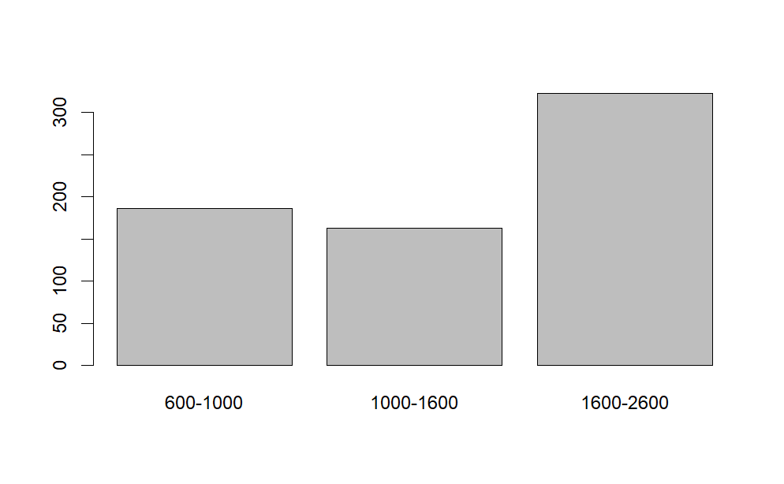

```r
#Bar Chart
Employees$Salary %>% table() %>% barplot()
```

Description of bar chart after discretization: After doing discretisation and observation, we noticed that the most values lie in approximately from 1600 to 2600. while from 600-1000 and 1000-1600 are close to each other. The range of Salaries has big difference, which we have to consider it for the classification and clustering.

#### 4.5.2 Convert Salary column to factor

```r
Employees$Salary <- as.factor(Employees$Salary)
```

#### 4.5.3 upscaling the data

```r
Employees <- upSample(Employees[,-8], Employees$Salary, yname="Salary")
Employees$Salary <- as.numeric(Employees$Salary)
Employees$Salary <- as.factor(Employees$Salary)
```

#### 4.5.4 checking the Salaries observations

```r
prop.table(table(Employees$Salary))
```

```
        1         2         3
0.3333333 0.3333333 0.3333333
```

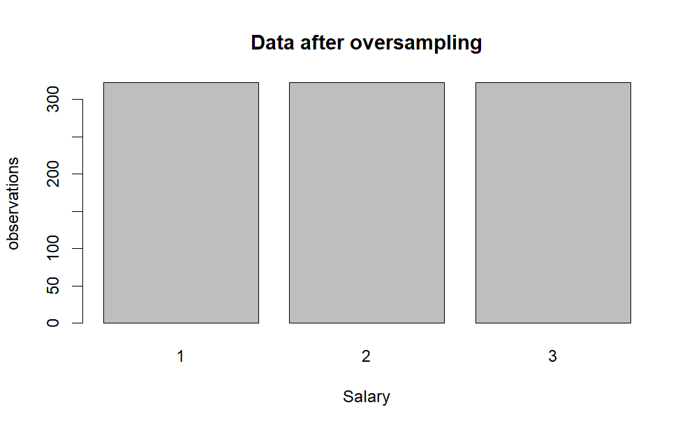

```r
plot(Employees$Salary)
title(main = "Data after oversampling", xlab = "Salary", ylab = "observations")
```

### 4.6.0 Data Normalization

Since we have a small range in our dataset, we don’t have to use the data normalization. As for the salary which has a large range; instead, we used data discretization that will help us in classification.

### 4.6.0 Data Factorisation

We applied it in classification section -5.0.0- which is important for applying classification technique. But we used it in a training set and testing set rather than the original which will affect the clustering technique.

##### Snapshot After applying Data preproccessing techniques:

```r
dim(Employees)
```

```
[1] 969  10
```

```r
str(Employees)
```

```
'data.frame':   969 obs. of  10 variables:
 $ ID         : chr  "2N75A9" "5Q42I5" "3A44X8" "6Q49W5" ...
 $ Education  : num  3 1 4 1 1 4 3 1 1 1 ...
 $ Department : num  20 15 6 21 20 15 20 3 4 15 ...
 $ Job Status : num  1 1 1 1 1 1 1 1 1 1 ...
 $ Location   : num  4 4 4 4 1 4 3 4 3 1 ...
 $ Start Date : POSIXct, format: "2014-01-13" ...
 $ Years      : num  6 3 3 4.34 7 ...
 $ Job Rate   : num  1 5 2 1 1 4 5 5 3 5 ...
 $ Permissions: num  13 2 11 10 1 6 3 10 4 1 ...
 $ Salary     : Factor w/ 3 levels "1","2","3": 1 1 1 1 1 1 1 1 1 1 ...
```

### 5.0.0 Data Mining Techniques

We employed both supervised and unsupervised learning methods on our dataset, utilizing techniques for classifying and grouping the data.

### 5.1.0 Classification

We used classification techniques to apply supervised learning to our data. We applied a decision tree for classification, which is a recursive method that generates a tree with leaf nodes pointing to the final decisions. Our model will predict the salary classification (600-1000, 1000-1600, 1600-2600). The rest of the attributes (education, job rate, job status, location, Years, Department and permission) are used to make the prediction. As for the ID, since it useless for information gain we did not use it. Also, to consume the complexity; we did not use the Start Date attribute. However, to be consistent we used the same formula for all methods except Gain ratio; since the decision tree will be complex, so we be content with Job Status, Job Rate , Department and Permissions which are the most 4 important attributes as mentioned in the feature selection.

The dataset is divided into two sets using this technique: The training set and the testing test. We need training data to train the model, so to achieve the greatest accuracy, we tried three different sizes of training subsets: 65%, 70%, and 75%, because the size of our dataset is limited. Because our model’s capacity to accurately forecast class label for new tuples is dependent on the operation of creating and training the model, we always assigned the training subset the largest percentage of our dataset.

```r
str(Employees)
```

```
'data.frame':   969 obs. of  10 variables:
 $ ID         : chr  "2N75A9" "5Q42I5" "3A44X8" "6Q49W5" ...
 $ Education  : num  3 1 4 1 1 4 3 1 1 1 ...
 $ Department : num  20 15 6 21 20 15 20 3 4 15 ...
 $ Job Status : num  1 1 1 1 1 1 1 1 1 1 ...
 $ Location   : num  4 4 4 4 1 4 3 4 3 1 ...
 $ Start Date : POSIXct, format: "2014-01-13" ...
 $ Years      : num  6 3 3 4.34 7 ...
 $ Job Rate   : num  1 5 2 1 1 4 5 5 3 5 ...
 $ Permissions: num  13 2 11 10 1 6 3 10 4 1 ...
 $ Salary     : Factor w/ 3 levels "1","2","3": 1 1 1 1 1 1 1 1 1 1 ...
```

#### 5.1.1 information gain Information gain

(rpart) is a measure used in decision tree algorithms. It is used to evaluate the quality of a split in a decision tree by measuring the reduction in entropy in the dataset. <sup>[3]</sup>

The information gain approach in rpart considers various potential splits based on different features in the dataset. For each split, the information gain is calculated by comparing the entropy of the original dataset with the weighted average of the entropies of the resulting subsets. The split that maximizes the information gain is chosen as the best split, as it leads to subsets with the highest level of homogeneity or purity.<sup>[3]</sup>

When building a decision tree using rpart, the algorithm iterates through all possible splits and selects the one with the highest information gain. This process is repeated recursively for each resulting subset until a stopping criterion is met, such as reaching a maximum tree depth or a minimum number of samples in a leaf node.

#### 5.1.2 Gini Index

Gini index (rpart) can be considered as a measure for the level of impurity in a dataset. When building the tree, decision tree algorithms frequently use it to determine the split’s quality.<sup>[4]</sup>

The approach takes into consideration several possible splits depending on distinct aspects in the dataset in order to employ the Gini index in a decision tree. Every split’s Gini index is computed, and the split with the lowest value is chosen. The selected split produces the resulting subsets with the best level of homogeneity or purity.<sup>[4]</sup>

#### 5.1.3 Gain Ratio

Gain ratio (C.50) is a measure utilized in decision tree algorithms to assess the quality of a split by considering both the information gain and the intrinsic information of a feature. It factors in the entropy or impurity of a dataset and the potential information obtained from dividing the data based on a specific feature.<sup>[5]</sup>

The algorithm examines the gain ratios of different features while employing the gain ratio under a decision tree, selecting the feature with the highest ratio as the ideal split. This will reduce the likelihood of bias toward attributes with a high number of values or categories.<sup>[5]</sup>

#### 5.2.0 Clustring

We used Clustering techniques to apply unsupervised learning to our data. Clustering groups similar data pointstogether based on some characteristics.The primary goal of clustering is to find natural groupings or clusters within our dataset without any prior knowledge of the groups. In this section we are going to partition our data using k-means. we are going to try three different k-means values which are (2,3 and 4).For each one we will calculate the average silhouette, total within-cluster sum of square and the BCubed precision and recall.

#### 5.2.1 Silhouette coefficient

The average silhouette coefficient used to evaluate the quality of clusters formed by a clustering algorithm, such as K-means or hierarchical clustering. It gives an overall evaluation of the suitability of the clustering and quantifies how well each data point fits into the designated cluster.

#### 5.2.2 BCubed precision and recall

BCubed is used to assess the quality of clustering results, It focuses on assessing the precision and recall of clustered data points concerning their true categories or classes. Precision of an object indicates how many other objects in the same cluster belong to the same category as the object. Recall of an object reflects how many objects of the same category are assigned to the same cluster.

#### 5.2.3 Total within-cluster sum of square

Total within-cluster sum of square measures the compactness or homogeneity of clusters by calculating the sum of squared distances between each data point and the centroid of its assigned cluster.

#### 5.2.4 Elbow method

(factoextra) pakage making easy to extract and visualize the output of exploratory multivariate data analyses. <sup>[6]</sup>

the elbow approach is a technique used to find the ideal number of clusters in a dataset. It aids in determining the point at which the number of clusters increases and the quality of clustering improves less and less.

### 6.0.0 Evaluation and comparison

#### 6.1.0 Classification

#### 6.1.1information gain

#### 6.1.2 information gain (70% , 30%)

```r
# 1.a fixed random seed to make results reproducible
set.seed(1234)
```

```r
# 2.Split the datasets into two subsets: Training(70%) and Testing(30%):
ind <- sample(2, nrow(Employees), replace = TRUE, prob = c(0.7, 0.3))
train.data <- Employees[ind == 1, ]
test.data <- Employees[ind == 2, ]
```

```r
# 3.Converting attribute to factor
train.data$Years <- factor(train.data$Years)
test.data$Years <- factor(test.data$Years)
train.data$'Job Rate' <- factor(train.data$'Job Rate')
test.data$'Job Rate' <- factor(test.data$'Job Rate')
train.data$Permissions <- factor(train.data$Permissions)
test.data$Permissions <- factor(test.data$Permissions)
train.data$ID <- factor(train.data$ID)
test.data$ID <- factor(test.data$ID)
train.data$'Start Date' <- factor(train.data$'Start Date')
test.data$'Start Date' <- factor(test.data$'Start Date')
train.data$Education <- factor(train.data$Education)
test.data$Education <- factor(test.data$Education)
train.data$Department <- factor(train.data$Department)
test.data$Department <- factor(test.data$Department)
train.data$'Job Status' <- factor(train.data$'Job Status')
test.data$'Job Status' <- factor(test.data$'Job Status')
train.data$Location <- factor(train.data$Location)
test.data$Location <- factor(test.data$Location)
```

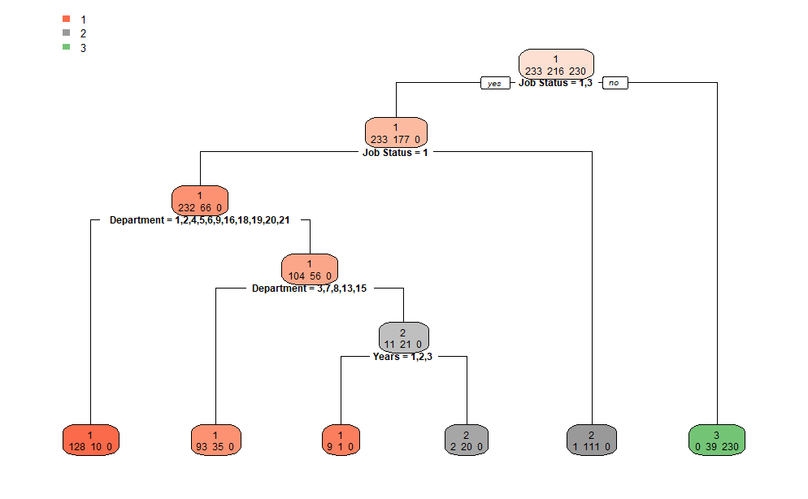

```r
# 4.Creating the tree
EmployeesTree <- rpart(Salary ~ Years + Education + Department + `Job Status` + Location + `Job Rate` + Permissions , data = train.data,parm=list(split="information"))

# 5.Visualize the decision tree using rpart.plot
rpart.plot(EmployeesTree, cex = 0.5, extra = 1)
```

```r
# 6.Make predictions on the test set
predictions <- predict(EmployeesTree, test.data, type = "class")  # Assuming it's a classification problem

# 7.Evaluate the accuracy of the predictions
accuracy <- sum(predictions == test.data$Salary) / nrow(test.data)


# 8.Confusion matrix
conf_matrix <- table(predictions, test.data$Salary)

# 9.Calculate evaluation metrics
TP <- conf_matrix[2, 2]  # True Positives
TN <- conf_matrix[1, 1]  # True Negatives
FP <- conf_matrix[2, 1]  # False Positives
FN <- conf_matrix[1, 2]  # False Negatives


# 10.Calculate precision
precision <- TP / (TP + FP)

# 11.Calculate sensitivity (True Positive Rate or Recall)
sensitivity <- TP / (TP + FN)

# 12.Calculate specificity (True Negative Rate)
specificity <- TN / (TN + FP)

# 13.Output the evaluation metrics
print(paste("Accuracy:", accuracy))
```

```
[1] "Accuracy: 0.841379310344828"
```

```r
print(paste("Precision:", precision))
```

```
[1] "Precision: 0.942028985507246"
```

```r
print(paste("Sensitivity (Recall):", sensitivity))
```

```
[1] "Sensitivity (Recall): 0.698924731182796"
```

```r
print(paste("Specificity:",specificity))
```

```
[1] "Specificity: 0.955555555555556"
```

##### Description of information gain tree (70% , 30%):

We can observe that we have 6 rules as we have 6 leaf nodes and 6 level, these are rules from the above tree:

▪ IF Job Status = 1,3 THEN it has more conditions

▪ IF Job status = 1 AND Department= 1,2,4,5,6,9,16,18,19,20,21 THEN Salary is 1.

▪ IF Job status = 1 AND Department != 1,2,4,5,6,9,16,18,19,20,21 AND Department = 3,7,8,13,15 THEN Salary is 1.

▪ IF Job status = 3 THEN Salary is 2.

▪ IF Job status != 1,3 THEN Salary is 3.

#### 6.1.3 information gain (75% , 25%)

```r
# 1.a fixed random seed to make results reproducible
set.seed(1234)
```

```r
# 2.Split the datasets into two subsets: Training(75%) and Testing(25%):
ind <- sample(2, nrow(Employees), replace = TRUE, prob = c(0.75, 0.25))
train.data <- Employees[ind == 1, ]
test.data <- Employees[ind == 2, ]
```

```r
# 3.Converting attribute to factor
train.data$Years <- factor(train.data$Years)
test.data$Years <- factor(test.data$Years)
train.data$'Job Rate' <- factor(train.data$'Job Rate')
test.data$'Job Rate' <- factor(test.data$'Job Rate')
train.data$Permissions <- factor(train.data$Permissions)
test.data$Permissions <- factor(test.data$Permissions)
train.data$ID <- factor(train.data$ID)
test.data$ID <- factor(test.data$ID)
train.data$'Start Date' <- factor(train.data$'Start Date')
test.data$'Start Date' <- factor(test.data$'Start Date')
train.data$Education <- factor(train.data$Education)
test.data$Education <- factor(test.data$Education)
train.data$Department <- factor(train.data$Department)
test.data$Department <- factor(test.data$Department)
train.data$'Job Status' <- factor(train.data$'Job Status')
test.data$'Job Status' <- factor(test.data$'Job Status')
train.data$Location <- factor(train.data$Location)
test.data$Location <- factor(test.data$Location)
```

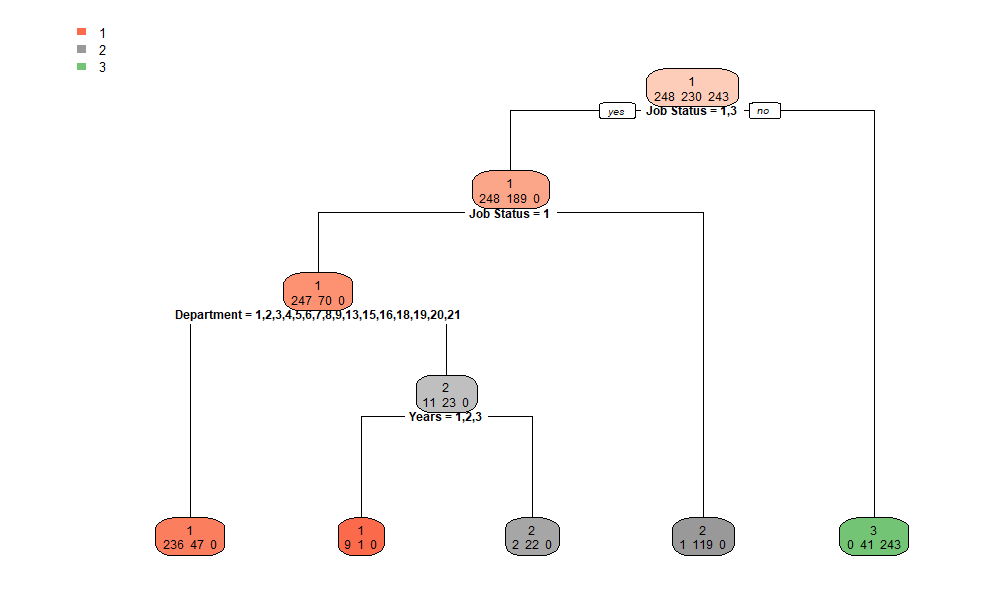

```r
# 4.Creating the tree
EmployeesTree <- rpart(Salary ~ Years + Education + Department + `Job Status` + Location + `Job Rate` + Permissions , data = train.data,parm=list(split="information"))

# 5.Visualize the decision tree using rpart.plot
rpart.plot(EmployeesTree, cex = 0.5, extra = 1)
```

```r
# 6.Make predictions on the test set
predictions <- predict(EmployeesTree, test.data, type = "class")  # Assuming it's a classification problem

# 7.Evaluate the accuracy of the predictions
accuracy <- sum(predictions == test.data$Salary) / nrow(test.data)



# 8.Confusion matrix
conf_matrix <- table(predictions, test.data$Salary)

# 9.Calculate evaluation metrics
TP <- conf_matrix[2, 2]  # True Positives
TN <- conf_matrix[1, 1]  # True Negatives
FP <- conf_matrix[2, 1]  # False Positives
FN <- conf_matrix[1, 2]  # False Negatives


# 10.Calculate precision
precision <- TP / (TP + FP)

# 11.Calculate sensitivity (True Positive Rate or Recall)
sensitivity <- TP / (TP + FN)

# 12.Calculate specificity (True Negative Rate)
specificity <- TN / (TN + FP)

# 13.Output the evaluation metrics
print(paste("Accuracy:", accuracy))
```

```
[1] "Accuracy: 0.834677419354839"
```

```r
print(paste("Precision:", precision))
```

```
[1] "Precision: 0.933333333333333"
```

```r
print(paste("Sensitivity (Recall):", sensitivity))
```

```
[1] "Sensitivity (Recall): 0.691358024691358"
```

```r
print(paste("Specificity:",specificity))
```

```
[1] "Specificity: 0.946666666666667"
```

##### Description of information gain tree (75% , 25%):

We can observe that we have 5 rules as we have 5 leaf nodes and 5 level, these are some rules from the above tree:

▪ IF Job Status = 1,3 THEN it has more conditions

▪ IF Job status = 1 AND Department= 1,2,3,4,5,6,7,8,9,13,15,16,18,19,20,21 THEN Salary is 1.

▪ IF Job status = 3 THEN Salary is 2.

▪ IF Job status != 1,3 THEN Salary is 3.

#### 6.1.4 information gain (65% , 35%)

```r
# 1.a fixed random seed to make results reproducible
set.seed(1234)
```

```r
# 2.Split the datasets into two subsets: Training(65%) and Testing(35%):
ind <- sample(2, nrow(Employees), replace = TRUE, prob = c(0.65, 0.35))
train.data <- Employees[ind == 1, ]
test.data <- Employees[ind == 2, ]
```

```r
# 3.Converting attribute to factor
train.data$Years <- factor(train.data$Years)
test.data$Years <- factor(test.data$Years)
train.data$'Job Rate' <- factor(train.data$'Job Rate')
test.data$'Job Rate' <- factor(test.data$'Job Rate')
train.data$Permissions <- factor(train.data$Permissions)
test.data$Permissions <- factor(test.data$Permissions)
train.data$ID <- factor(train.data$ID)
test.data$ID <- factor(test.data$ID)
train.data$'Start Date' <- factor(train.data$'Start Date')
test.data$'Start Date' <- factor(test.data$'Start Date')
train.data$Education <- factor(train.data$Education)
test.data$Education <- factor(test.data$Education)
train.data$Department <- factor(train.data$Department)
test.data$Department <- factor(test.data$Department)
train.data$'Job Status' <- factor(train.data$'Job Status')
test.data$'Job Status' <- factor(test.data$'Job Status')
train.data$Location <- factor(train.data$Location)
test.data$Location <- factor(test.data$Location)
```

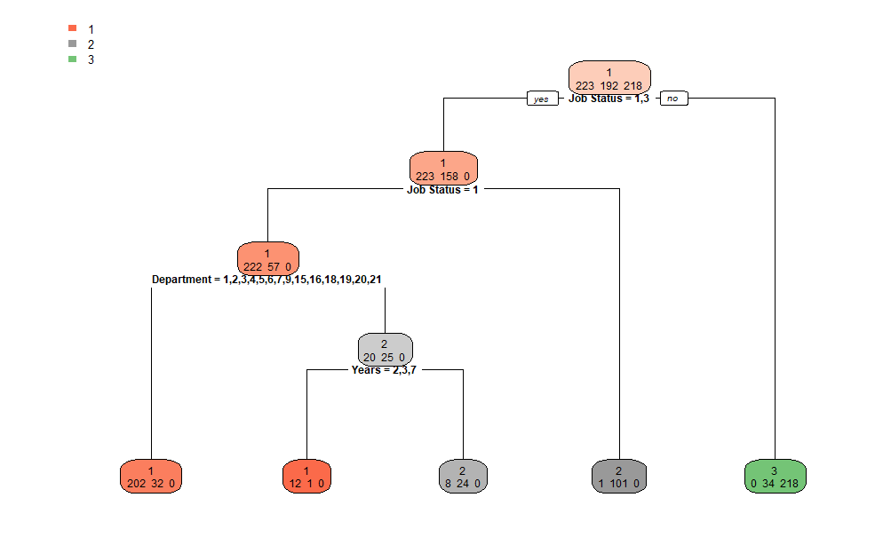

```r
# 4.Creating the tree
EmployeesTree <- rpart(Salary ~ Years + Education + Department + `Job Status` + Location + `Job Rate` + Permissions , data = train.data,parm=list(split="information"))

# 5.Visualize the decision tree using rpart.plot
rpart.plot(EmployeesTree, cex = 0.5, extra = 1)
```

```r
# 6.Make predictions on the test set
predictions <- predict(EmployeesTree, test.data, type = "class")  # Assuming it's a classification problem

# 7.Evaluate the accuracy of the predictions
accuracy <- sum(predictions == test.data$Salary) / nrow(test.data)

# 8.Confusion matrix
conf_matrix <- table(predictions, test.data$Salary)

# 9.Calculate evaluation metrics
TP <- conf_matrix[2, 2]  # True Positives
TN <- conf_matrix[1, 1]  # True Negatives
FP <- conf_matrix[2, 1]  # False Positives
FN <- conf_matrix[1, 2]  # False Negatives


# 10.Calculate precision
precision <- TP / (TP + FP)

# 11.Calculate sensitivity (True Positive Rate or Recall)
sensitivity <- TP / (TP + FN)

# 12.Calculate specificity (True Negative Rate)
specificity <- TN / (TN + FP)

# 13.Output the evaluation metrics
print(paste("Accuracy:", accuracy))
```

```
[1] "Accuracy: 0.81547619047619"
```

```r
print(paste("Precision:", precision))
```

```
[1] "Precision: 0.887640449438202"
```

```r
print(paste("Sensitivity (Recall):", sensitivity))
```

```
[1] "Sensitivity (Recall): 0.705357142857143"
```

```r
print(paste("Specificity:",specificity))
```

```
[1] "Specificity: 0.9"
```

##### Description of information gain tree (65% , 35%):

We can observe that we have 5 rules as we have 5 leaf nodes and 5 level, these are some rules from the above tree:

▪ IF Job Status = 1,3 THEN it has more conditions

▪ IF Job status = 1 AND Job Status = 1 AND Department= 1,2,3,4,5,6,7,9,15,16, 18,19,20,21 THEN Salary is 1.

▪ IF Job status = 1 AND Job Status = 1 AND Department != 1,2,3,4,5,6,7,9,15,16, 18,19,20,21 Years = 2,3,7 THEN Salary is 1.

▪ IF Job status = 3 THEN Salary is 2.

▪ IF Job status != 1,3 THEN Salary is 3.

#### 6.1.5 Comparison:

##### Table 2

| Information Gain | 70% Train , 30% Test | 75% Train , 25% Test | 65% Train , 35% Test |
| --- | --- | --- | --- |
| Accuracy | 84% | 83% | 81% |
| Precision | 94% | 93% | 88% |
| Sensitivity | 69% | 69% | 70% |
| Specificity | 95% | 94% | 90% |

#### 6.1.6 Discussion:

The accuracy metric measures the overall correctness of the model’s predictions. The 70% Train , 30% Test partitions has higher accuracy compared to other.

Precision measures the proportion of correctly predicted positive instances out of the total instances predicted as positive. The 70% Train, 30% Test partition has the highest precision, followed by the 75% Train, 25% Test partition , and then the 65% Train, 35% Test partition.

Specificity measures the proportion of actual negative instances correctly identified by the model. The the 70% Train, 30% Test partition has the highest specificity, followed by the 75% Train, 25% Test partition, and then 65% Train, 35% Test partition.

In summary, the performance of the information gain partition varies depending on the train-test split percentages. The 75% Train, 25% Test and 70% Train , 30% Test partitions generally outperform the 65% Train , 35% Test partition in terms of accuracy, precision, Specificity. However, the 65% Train , 35% Test partition has the highest Sensitivity.

#### 6.1.7 Gini Index

#### 6.1.8 Gini Index (70% , 30%)

```r
# 1.a fixed random seed to make results reproducible
set.seed(1234)
```

```r
# 2.Split the datasets into two subsets: Training(70%) and Testing(30%):
ind <- sample(2, nrow(Employees), replace = TRUE, prob = c(0.7, 0.3))
train_data <- Employees[ind == 1, ]
test_data <- Employees[ind == 2, ]
```

```r
# 3.Converting attribute to factor
train_data$Years <- factor(train_data$Years)
test_data$Years <- factor(test_data$Years)
train_data$'Job Rate' <- factor(train_data$'Job Rate')
test_data$'Job Rate' <- factor(test_data$'Job Rate')
train_data$Permissions <- factor(train_data$Permissions)
test_data$Permissions <- factor(test_data$Permissions)
train_data$ID <- factor(train_data$ID)
test_data$ID <- factor(test_data$ID)
train_data$'Start Date' <- factor(train_data$'Start Date')
test_data$'Start Date' <- factor(test_data$'Start Date')
train_data$Education <- factor(train_data$Education)
test_data$Education <- factor(test_data$Education)
train_data$Department <- factor(train_data$Department)
test_data$Department <- factor(test_data$Department)
train_data$'Job Status' <- factor(train_data$'Job Status')
test_data$'Job Status' <- factor(test_data$'Job Status')
train_data$Location <- factor(train_data$Location)
test_data$Location <- factor(test_data$Location)
```

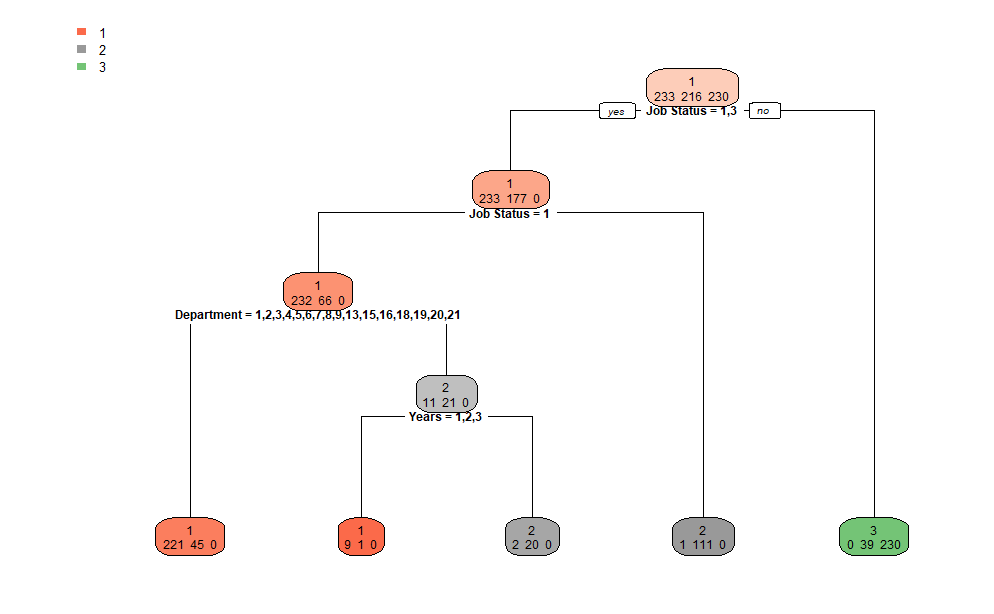

```r
# 4.Creating the tree
EmployeesTree <- rpart(Salary ~ Years + Education + Department + `Job Status` + Location + `Job Rate` + Permissions , data = train_data,parm=list(split="gini"))

# 5.Visualize the decision tree using rpart.plot
rpart.plot(EmployeesTree, cex = 0.5, extra = 1)
```

```r
# 6.Make predictions on the test set
predictions <- predict(EmployeesTree, test_data, type = "class")  # Assuming it's a classification problem

# 7.Evaluate the accuracy of the predictions
accuracy <- sum(predictions == test_data$Salary) / nrow(test_data)

# 8.Confusion matrix
conf_matrix <- table(predictions, test_data$Salary)

# 9.Calculate evaluation metrics
TP <- conf_matrix[2, 2]  # True Positives
TN <- conf_matrix[1, 1]  # True Negatives
FP <- conf_matrix[2, 1]  # False Positives
FN <- conf_matrix[1, 2]  # False Negatives


# 10.Calculate precision
precision <- TP / (TP + FP)

# 11.Calculate sensitivity (True Positive Rate or Recall)
sensitivity <- TP / (TP + FN)

# 12.Calculate specificity (True Negative Rate)
specificity <- TN / (TN + FP)

# 13.Output the evaluation metrics
print(paste("Accuracy:", accuracy))
```

```
[1] "Accuracy: 0.841379310344828"
```

```r
print(paste("Precision:", precision))
```

```
[1] "Precision: 0.942028985507246"
```

```r
print(paste("Sensitivity (Recall):", sensitivity))
```

```
[1] "Sensitivity (Recall): 0.698924731182796"
```

```r
print(paste("Specificity:",specificity))
```

```
[1] "Specificity: 0.955555555555556"
```

##### Description of Gini Index tree (70% , 30%):

We can observe that we have 5 rules as we have 5 leaf nodes and 5 level, these are rules from the above tree:

▪ IF Job Status = 1,3 THEN it has more conditions

▪ IF Job status = 1 AND Department= 1,2,3,4,5,6,7,8,9,13,15,16,18,19,20,21 THEN Salary is 1.

▪ IF Job status = 1 AND Department != 1,2,3,4,5,6,7,8,9,13,15,16,18,19,20,21 AND Years = 1,2,3 THEN Salary is 1.

▪ IF Job status = 1 AND Department != 1,2,3,4,5,6,7,8,9,13,15,16,18,19,20,21 AND Years != 1,2,3 THEN Salary is 2.

▪ IF Job status = 3 THEN Salary is 2.

▪ IF Job status != 1,3 THEN Salary is 3.

#### 6.1.9 Gini Index (75% , 25%)

```r
# 1.a fixed random seed to make results reproducible
set.seed(1234)
```

```r
# 2.Split the datasets into two subsets: Training(75%) and Testing(25%):
ind <- sample(2, nrow(Employees), replace = TRUE, prob = c(0.75, 0.25))
train_data <- Employees[ind == 1, ]
test_data <- Employees[ind == 2, ]
```

```r
# 3.Converting attribute to factor
train_data$Years <- factor(train_data$Years)
test_data$Years <- factor(test_data$Years)
train_data$'Job Rate' <- factor(train_data$'Job Rate')
test_data$'Job Rate' <- factor(test_data$'Job Rate')
train_data$Permissions <- factor(train_data$Permissions)
test_data$Permissions <- factor(test_data$Permissions)
train_data$ID <- factor(train_data$ID)
test_data$ID <- factor(test_data$ID)
train_data$'Start Date' <- factor(train_data$'Start Date')
test_data$'Start Date' <- factor(test_data$'Start Date')
train_data$Education <- factor(train_data$Education)
test_data$Education <- factor(test_data$Education)
train_data$Department <- factor(train_data$Department)
test_data$Department <- factor(test_data$Department)
train_data$'Job Status' <- factor(train_data$'Job Status')
test_data$'Job Status' <- factor(test_data$'Job Status')
train_data$Location <- factor(train_data$Location)
test_data$Location <- factor(test_data$Location)
```

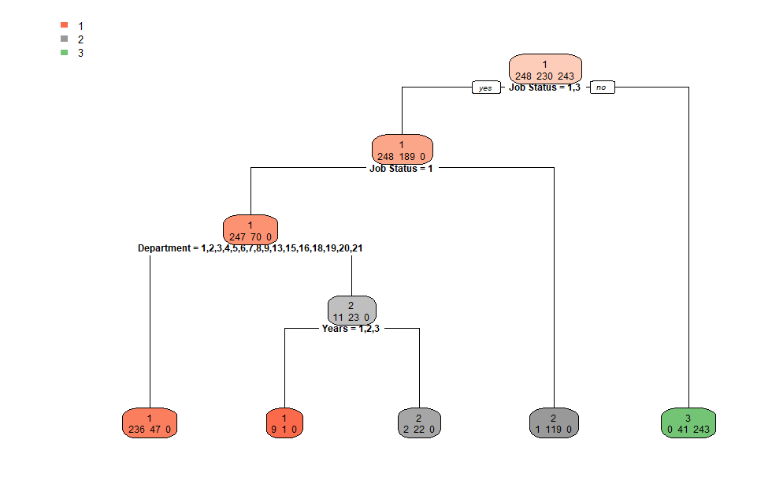

```r
# 4.Creating the tree
EmployeesTree <- rpart(Salary ~ Years + Education + Department + `Job Status` + Location + `Job Rate` + Permissions , data = train_data,parm=list(split="gini"))

# 5.Visualize the decision tree using rpart.plot
rpart.plot(EmployeesTree, cex = 0.5, extra = 1)
```

```r
# 6.Make predictions on the test set
predictions <- predict(EmployeesTree, test_data, type = "class")  # Assuming it's a classification problem

# 7.Evaluate the accuracy of the predictions
accuracy <- sum(predictions == test_data$Salary) / nrow(test_data)

# 8.Confusion matrix
conf_matrix <- table(predictions, test_data$Salary)

# 9.Calculate evaluation metrics
TP <- conf_matrix[2, 2]  # True Positives
TN <- conf_matrix[1, 1]  # True Negatives
FP <- conf_matrix[2, 1]  # False Positives
FN <- conf_matrix[1, 2]  # False Negatives


# 10.Calculate precision
precision <- TP / (TP + FP)

# 11.Calculate sensitivity (True Positive Rate or Recall)
sensitivity <- TP / (TP + FN)

# 12.Calculate specificity (True Negative Rate)
specificity <- TN / (TN + FP)

# 13.Output the evaluation metrics
print(paste("Accuracy:", accuracy))
```

```
[1] "Accuracy: 0.834677419354839"
```

```r
print(paste("Precision:", precision))
```

```
[1] "Precision: 0.933333333333333"
```

```r
print(paste("Sensitivity (Recall):", sensitivity))
```

```
[1] "Sensitivity (Recall): 0.691358024691358"
```

```r
print(paste("Specificity:",specificity))
```

```
[1] "Specificity: 0.946666666666667"
```

##### Description of Gini Index tree (75% , 25%):

We can observe that we have 5 rules as we have 5 leaf nodes and 5 level, these are some rules from the above tree:

▪ IF Job Status = 1,3 THEN it has more conditions

▪ IF Job status = 1 AND Department= 1,2,3,4,5,6,7,8,9,13,15,16,18,19,20,21 THEN Salary is 1.

▪ IF Job status = 1 AND Department != 1,2,3,4,5,6,7,8,9,13,15,16,18,19,20,21 AND Years = 1,2,3 THEN Salary is 1.

▪ IF Job status = 1 AND Department != 1,2,3,4,5,6,7,8,9,13,15,16,18,19,20,21 AND Years != 1,2,3 THEN Salary is 2.

▪ IF Job status = 3 THEN Salary is 2.

▪ IF Job status != 1,3 THEN Salary is 3.

#### 6.1.10 Gini Index (65% , 35%)

```r
# 1.a fixed random seed to make results reproducible
set.seed(1234)
```

```r
# 2.Split the datasets into two subsets: Training(65%) and Testing(35%):
ind <- sample(2, nrow(Employees), replace = TRUE, prob = c(0.65, 0.35))
train_data <- Employees[ind == 1, ]
test_data <- Employees[ind == 2, ]
```

```r
# 3.Converting attribute to factor
train_data$Years <- factor(train_data$Years)
test_data$Years <- factor(test_data$Years)
train_data$'Job Rate' <- factor(train_data$'Job Rate')
test_data$'Job Rate' <- factor(test_data$'Job Rate')
train_data$Permissions <- factor(train_data$Permissions)
test_data$Permissions <- factor(test_data$Permissions)
train_data$ID <- factor(train_data$ID)
test_data$ID <- factor(test_data$ID)
train_data$'Start Date' <- factor(train_data$'Start Date')
test_data$'Start Date' <- factor(test_data$'Start Date')
train_data$Education <- factor(train_data$Education)
test_data$Education <- factor(test_data$Education)
train_data$Department <- factor(train_data$Department)
test_data$Department <- factor(test_data$Department)
train_data$'Job Status' <- factor(train_data$'Job Status')
test_data$'Job Status' <- factor(test_data$'Job Status')
train_data$Location <- factor(train_data$Location)
test_data$Location <- factor(test_data$Location)
```

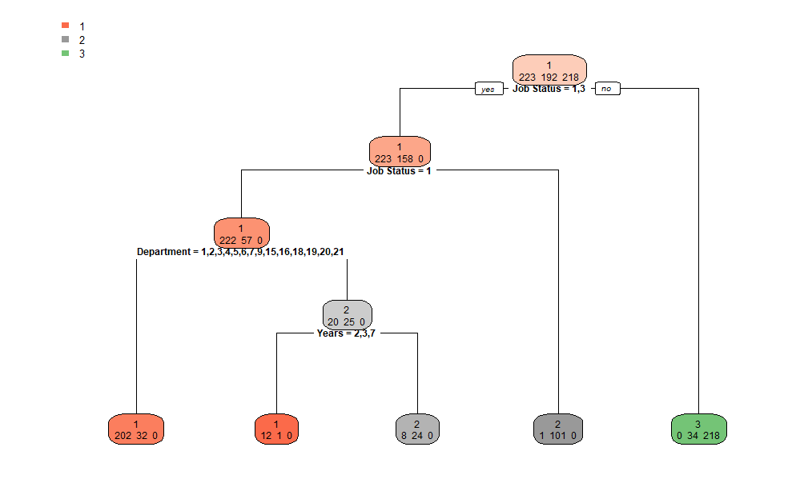

```r
# 4.Creating the tree
EmployeesTree <- rpart(Salary ~ Years + Education + Department + `Job Status` + Location + `Job Rate` + Permissions , data = train_data,parm=list(split="gini"))

# 5.Visualize the decision tree using rpart.plot
rpart.plot(EmployeesTree, cex = 0.5, extra = 1)
```

```r
# 6.Make predictions on the test set
predictions <- predict(EmployeesTree, test_data, type = "class")  # Assuming it's a classification problem

# 7.Evaluate the accuracy of the predictions
accuracy <- sum(predictions == test_data$Salary) / nrow(test_data)

# 8.Confusion matrix
conf_matrix <- table(predictions, test_data$Salary)

# 9.Calculate evaluation metrics
TP <- conf_matrix[2, 2]  # True Positives
TN <- conf_matrix[1, 1]  # True Negatives
FP <- conf_matrix[2, 1]  # False Positives
FN <- conf_matrix[1, 2]  # False Negatives


# 10.Calculate precision
precision <- TP / (TP + FP)

# 11.Calculate sensitivity (True Positive Rate or Recall)
sensitivity <- TP / (TP + FN)

# 12.Calculate specificity (True Negative Rate)
specificity <- TN / (TN + FP)

# 13.Output the evaluation metrics
print(paste("Accuracy:", accuracy))
```

```
[1] "Accuracy: 0.81547619047619"
```

```r
print(paste("Precision:", precision))
```

```
[1] "Precision: 0.887640449438202"
```

```r
print(paste("Sensitivity (Recall):", sensitivity))
```

```
[1] "Sensitivity (Recall): 0.705357142857143"
```

```r
print(paste("Specificity:",specificity))
```

```
[1] "Specificity: 0.9"
```

##### Description of Gini Index tree (65% , 35%):

We can observe that we have 5 rules as we have 5 leaf nodes and 5 level, these are some rules from the above tree:

▪ IF Job Status = 1,3 THEN it has more conditions

IF Job status = 1 AND Job Status = 1 AND Department= 1,2,3,4,5,6,7,9,15,16, 18,19,20,21 THEN Salary is 1.

IF Job status = 1 AND Job Status = 1 AND Department != 1,2,3,4,5,6,7,9,15,16, 18,19,20,21 AND Years = 2,3,7 THEN Salary is 1.

IF Job status = 3 THEN Salary is 2.

▪ IF Job status != 1,3 THEN Salary is 3.

#### 6.1.11 Comparison:

##### Table 3

[output not shown]

#### 6.1.12 Discussion:

The accuracy metric measures the overall correctness of the model’s predictions. The 70% Train, 30% Test partition has the highest accuracy, followed by the 75% Train, 25% Test partition, and then the 65% Train, 35% Test partition.

Precision measures the proportion of correctly predicted positive instances out of the total instances predicted as positive. The 70% Train, 30% Test partition has the highest precision, followed by the 75% Train, 25% Test partition, and then the 65% Train, 35% Test partition.

Specificity measures the proportion of actual negative instances correctly identified by the model. he 70% Train, 30% Test partition has the highest specificity, followed by the 75% Train, 25% Test partition, and then the 65% Train, 35% Test partition.

In summary, the performance of the Gini Index partition also varies depending on the train-test split percentages. The 70% Train, 30% Test partition generally outperforms the other partitions in terms of accuracy, precision and specificity, followed by 70% Train, 30% Test partition. However, the 65% Train, 35% Test partition has the highest sensitivity.

#### 6.1.13 Gain Ratio

#### 6.1.14 Gain Ratio (70% , 30%)

```r
# 1.a fixed random seed to make results reproducible
set.seed(1234)
```

```r
# 2.Split the datasets into two subsets: Training(70%) and Testing(30%):
train_indices <- sample(1:nrow(Employees), nrow(Employees) * 0.7)
trainData <- Employees[train_indices, ]
testData <- Employees[-train_indices , ]
```

```r
# 3.Converting attribute to factor
trainData$Years <- factor(trainData$Years)
testData$Years <- factor(testData$Years)
trainData$'Job Rate' <- factor(trainData$'Job Rate')
testData$'Job Rate' <- factor(testData$'Job Rate')
trainData$Permissions <- factor(trainData$Permissions)
testData$Permissions <- factor(testData$Permissions)
trainData$ID <- factor(trainData$ID)
testData$ID <- factor(testData$ID)
trainData$'Start Date' <- factor(trainData$'Start Date')
testData$'Start Date' <- factor(testData$'Start Date')
trainData$Education <- factor(trainData$Education)
testData$Education <- factor(testData$Education)
trainData$Department <- factor(trainData$Department)
testData$Department <- factor(testData$Department)
trainData$'Job Status' <- factor(trainData$'Job Status')
testData$'Job Status' <- factor(testData$'Job Status')
trainData$Location <- factor(trainData$Location)
testData$Location <- factor(testData$Location)
trainData$Salary <- factor(trainData$Salary)
testData$Salary <- factor(testData$Salary)
```

```r
# 4.Creating the tree
model1 <- C5.0(Salary ~ `Job Status` + `Job Rate` + Permissions, data = trainData)

# 5.Make predictions on the test set
predictions <- predict(model1, testData, type = "class")

# 6.Evaluate the accuracy of the predictions
accuracy <- sum(predictions == testData$Salary) / nrow(testData)

# 7.Confusion matrix
conf_matrix <- table(predictions, testData$Salary)

# 8.Calculate evaluation metrics
TP <- conf_matrix[2, 2]  # True Positives
TN <- conf_matrix[1, 1]  # True Negatives
FP <- conf_matrix[2, 1]  # False Positives
FN <- conf_matrix[1, 2]  # False Negatives


# 9.Calculate precision
precision <- TP / (TP + FP)

# 10.Calculate sensitivity (True Positive Rate or Recall)
sensitivity <- TP / (TP + FN)

# 11.Calculate specificity (True Negative Rate)
specificity <- TN / (TN + FP)

# 12.Output the evaluation metrics
print(paste("Accuracy:", accuracy))
```

```
[1] "Accuracy: 0.859106529209622"
```

```r
print(paste("Precision:", precision))
```

```
[1] "Precision: 0.980769230769231"
```

```r
print(paste("Sensitivity (Recall):", sensitivity))
```

```
[1] "Sensitivity (Recall): 0.671052631578947"
```

```r
print(paste("Specificity:",specificity))
```

```
[1] "Specificity: 0.990196078431373"
```

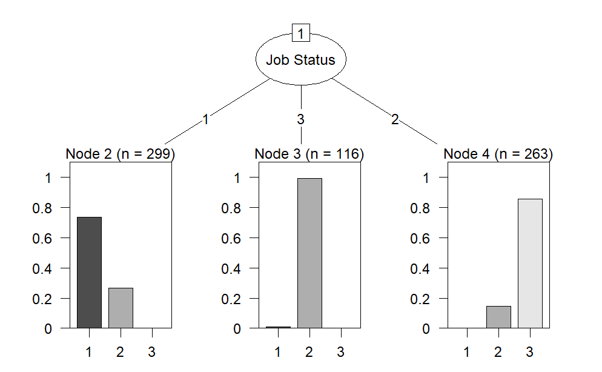

```r
# 13.Visualize the decision tree using plot
plot(model1)
```

##### Description of Gain Ratio tree (70% , 30%):

We can observe that we have 3 rules as we have 3 leaf nodes and 1 level, these are some rules from the above tree:

▪ IF Job Status = 1 THEN Salary is 1.

▪ IF Job Status = 3 THEN Salary is 2.

▪ IF Job Status = 2 THEN Salary is 3.

#### 6.1.15 Gain Ratio (75% , 25%)

```r
# 1.a fixed random seed to make results reproducible
set.seed(1234)
```

```r
# 2.Split the datasets into two subsets: Training(75%) and Testing(25%):
train_indices <- sample(1:nrow(Employees), nrow(Employees) * 0.75)
trainData <- Employees[train_indices, ]
testData <- Employees[-train_indices , ]
```

```r
# 3.Converting attribute to factor
trainData$Years <- factor(trainData$Years)
testData$Years <- factor(testData$Years)
trainData$'Job Rate' <- factor(trainData$'Job Rate')
testData$'Job Rate' <- factor(testData$'Job Rate')
trainData$Permissions <- factor(trainData$Permissions)
testData$Permissions <- factor(testData$Permissions)
trainData$ID <- factor(trainData$ID)
testData$ID <- factor(testData$ID)
trainData$'Start Date' <- factor(trainData$'Start Date')
testData$'Start Date' <- factor(testData$'Start Date')
trainData$Education <- factor(trainData$Education)
testData$Education <- factor(testData$Education)
trainData$Department <- factor(trainData$Department)
testData$Department <- factor(testData$Department)
trainData$'Job Status' <- factor(trainData$'Job Status')
testData$'Job Status' <- factor(testData$'Job Status')
trainData$Location <- factor(trainData$Location)
testData$Location <- factor(testData$Location)
trainData$Salary <- factor(trainData$Salary)
testData$Salary <- factor(testData$Salary)
```

```r
# 4.Creating the tree
model2 <- C5.0(Salary ~ `Job Status` + `Job Rate` + Department + Permissions, data = trainData, control = C5.0Control(CF = 0.1))

# 5.Make predictions on the test set
predictions <- predict(model2, testData, type = "class")

# 6.Evaluate the accuracy of the predictions
accuracy <- sum(predictions == testData$Salary) / nrow(testData)


# 7.Confusion matrix
conf_matrix <- table(predictions, testData$Salary)

# 8.Calculate evaluation metrics
TP <- conf_matrix[2, 2]  # True Positives
TN <- conf_matrix[1, 1]  # True Negatives
FP <- conf_matrix[2, 1]  # False Positives
FN <- conf_matrix[1, 2]  # False Negatives


# 9.Calculate precision
precision <- TP / (TP + FP)

# 10.Calculate sensitivity (True Positive Rate or Recall)
sensitivity <- TP / (TP + FN)

# 11.Calculate specificity (True Negative Rate)
specificity <- TN / (TN + FP)

# 12.Output the evaluation metrics
print(paste("Accuracy:", accuracy))
```

```
[1] "Accuracy: 0.851851851851852"
```

```r
print(paste("Precision:", precision))
```

```
[1] "Precision: 0.872727272727273"
```

```r
print(paste("Sensitivity (Recall):", sensitivity))
```

```
[1] "Sensitivity (Recall): 0.738461538461539"
```

```r
print(paste("Specificity:",specificity))
```

```
[1] "Specificity: 0.918604651162791"
```

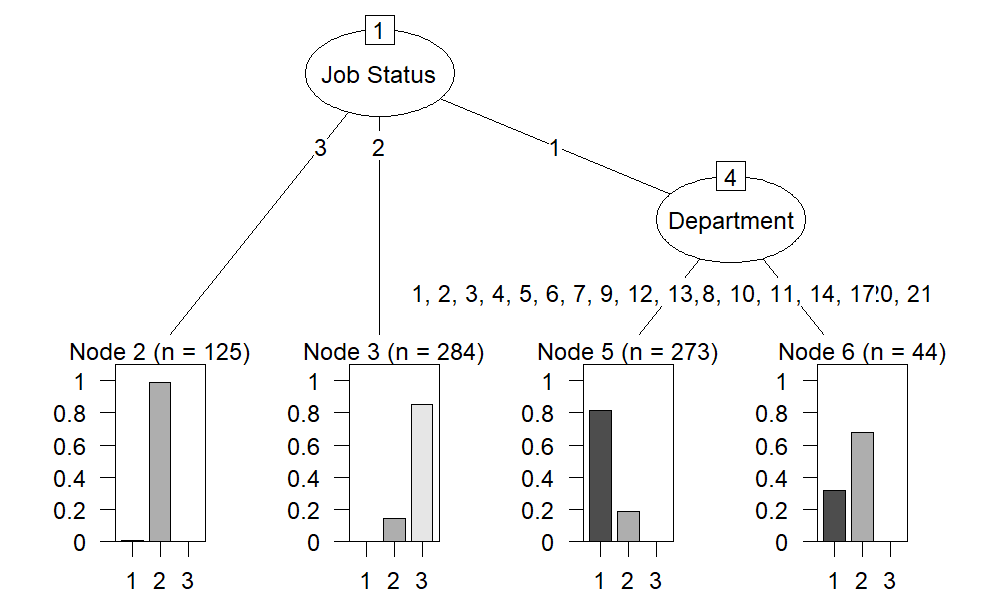

```r
# 13.Visualize the decision tree using plot
plot(model2)
```

##### Description of Gain Ratio tree (75% , 25%):

▪ IF Job Status = 1 AND Department = 20,21 THEN Salary is 2.

▪ IF Job Status = 3 THEN Salary is 2.

▪ IF Job Status = 2 THEN Salary is 3.

#### 6.1.16 Gain Ratio (65% , 35%)

```r
# 1.a fixed random seed to make results reproducible
set.seed(1234)
```

```r
# 2.Split the datasets into two subsets: Training(65%) and Testing(35%):
train_indices <- sample(1:nrow(Employees), nrow(Employees) * 0.65)
trainData <- Employees[train_indices, ]
testData <- Employees[-train_indices , ]
```

```r
# 3.Converting attribute to factor
trainData$Years <- factor(trainData$Years)
testData$Years <- factor(testData$Years)
trainData$'Job Rate' <- factor(trainData$'Job Rate')
testData$'Job Rate' <- factor(testData$'Job Rate')
trainData$Permissions <- factor(trainData$Permissions)
testData$Permissions <- factor(testData$Permissions)
trainData$ID <- factor(trainData$ID)
testData$ID <- factor(testData$ID)
trainData$'Start Date' <- factor(trainData$'Start Date')
testData$'Start Date' <- factor(testData$'Start Date')
trainData$Education <- factor(trainData$Education)
testData$Education <- factor(testData$Education)
trainData$Department <- factor(trainData$Department)
testData$Department <- factor(testData$Department)
trainData$'Job Status' <- factor(trainData$'Job Status')
testData$'Job Status' <- factor(testData$'Job Status')
trainData$Location <- factor(trainData$Location)
testData$Location <- factor(testData$Location)
trainData$Salary <- factor(trainData$Salary)
testData$Salary <- factor(testData$Salary)
```

```r
# 4.Train a CART model
model3 <- C5.0(Salary ~ `Job Status` + `Job Rate` + Department + Permissions, data = trainData, control = C5.0Control(CF = 0.1))


# 5.Make predictions on the test dataset
predictions <- predict(model3, testData, type = "class")


# 6.Evaluate the accuracy of the predictions
accuracy <- sum(predictions == testData$Salary) / nrow(testData)


# 7.Confusion matrix
conf_matrix <- table(predictions, testData$Salary)

# 8.Calculate evaluation metrics
TP <- conf_matrix[2, 2]  # True Positives
TN <- conf_matrix[1, 1]  # True Negatives
FP <- conf_matrix[2, 1]  # False Positives
FN <- conf_matrix[1, 2]  # False Negatives


# 9.Calculate precision
precision <- TP / (TP + FP)

# 10.Calculate sensitivity (True Positive Rate or Recall)
sensitivity <- TP / (TP + FN)

# 11.Calculate specificity (True Negative Rate)
specificity <- TN / (TN + FP)

# 12.Output the evaluation metrics
print(paste("Accuracy:", accuracy))
```

```
[1] "Accuracy: 0.829411764705882"
```

```r
print(paste("Precision:", precision))
```

```
[1] "Precision: 0.873239436619718"
```

```r
print(paste("Sensitivity (Recall):", sensitivity))
```

```
[1] "Sensitivity (Recall): 0.659574468085106"
```

```r
print(paste("Specificity:",specificity))
```

```
[1] "Specificity: 0.921739130434783"
```

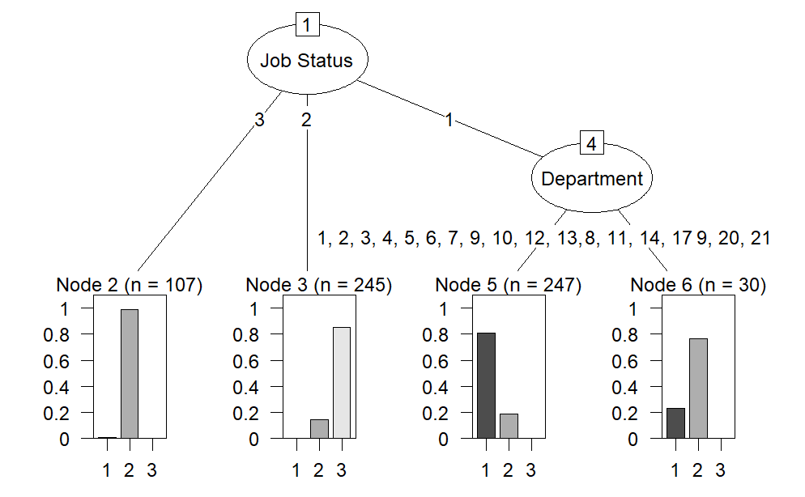

```r
# 13.Visualize the decision tree using plot
plot(model3)
```

##### Description of Gain Ratio tree (65% , 35%):

▪ IF Job Status = 1 AND Department = 19,20,21 THEN Salary is 2.

▪ IF Job Status = 3 THEN Salary is 2.

▪ IF Job Status = 2 THEN Salary is 3.

#### 6.1.17 Comparison:

##### Table 4

| Gain Ratio | 70% Train , 30% Test | 75% Train , 25% Test | 65% Train , 35% Test |
| --- | --- | --- | --- |
| Accuracy | 85% | 85% | 82% |
| Precision | 98% | 87% | 87% |
| Sensitivity | 67% | 73% | 65% |
| Specificity | 99% | 91% | 92% |

#### 6.1.18 Discussion:

The accuracy metric measures the overall correctness of the model’s predictions. The 70% Train, 30% Test and 75% Train, 25% Test partitions have the highest accuracy, followed by the 65% Train, 35% Test partition.

Precision measures the proportion of correctly predicted positive instances out of the total instances predicted as positive. The 70% Train, 30% Test has the highest precision, while the 75% Train, 25% Test and 65% Train, 35% Test partitions has the same precision.

Sensitivity, also known as recall or true positive rate, measures the proportion of actual positive instances correctly identified by the model. The besr sensitivity value appear in 75% Train, 25% Test partition, while others have a similar values.

#### 6.2.0 Clustring

We randomly selected 3 values for k-means, we have selected k=2, k=3 and k=4 to test them to find the optimal K.

#### 6.2.1 First K-mean (k=2)

1. Deleting columns

```r
Sal <- Employees$Salary
##Delete columns
Employees <- Employees[, !names(Employees) %in% c("Salary","ID", "Start Date")]
```

Reason for removing some columns: We removed “Salary” because it is our class label and we are dealing with an unsupervised learning technique which means we don’t need the class label. We removed ” Start Date” because it had “unknown” type and it was not possible to convert its type to numric in order to start with clustering. We as well removed “ID” because it is of type “character” and converting it to numric will help us with nothing in our dataset.

2. Creating two clusters # Cluster k=2

```r
# calculate k-mean k=2
km <- kmeans(Employees, centers= 2, iter.max = 100 , algorithm="Lloyd", nstart=100)
km
```

```
K-means clustering with 2 clusters of sizes 554, 415

Cluster means:
  Education Department Job Status Location    Years Job Rate
1  2.357401   6.509025   1.776173 2.812274 4.420124 4.866426
2  2.371084  16.356627   1.679518 2.766265 4.291667 4.657831
  Permissions
1    7.034296
2    6.968675

Clustering vector:
  [1] 2 2 1 2 2 2 2 1 1 2 1 1 2 1 2 1 2 1 1 1 2 2 2 1 2 2 2 2 1 2 1 1 1
 [34] 1 1 2 1 2 2 2 2 1 1 1 1 2 1 1 1 1 1 1 1 1 1 1 2 1 2 2 2 2 1 2 1 1
 [67] 1 2 1 2 1 2 2 2 1 2 1 1 2 1 1 2 2 2 1 2 1 1 1 2 1 2 2 2 2 1 1 2 2
[100] 1 1 1 1 2 2 2 2 2 1 2 2 2 1 2 2 1 1 2 2 2 1 1 2 1 2 1 1 2 2 1 1 2
```

[output cut: 36 more lines]

3. visualizing the result in graphical format of two clusters

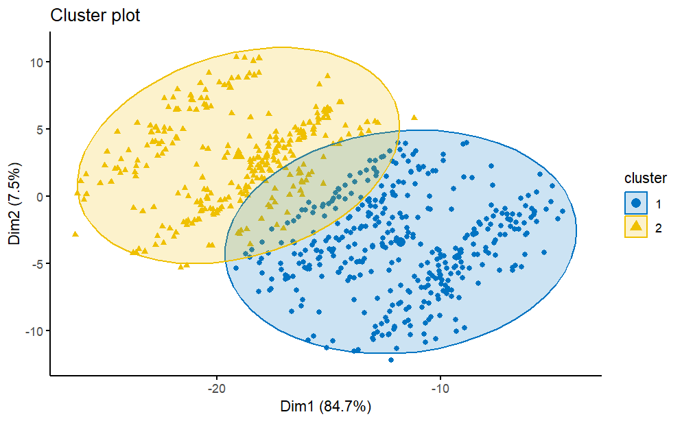

```r
# plot k-mean
fviz_cluster(list(data = Employees, cluster = km$cluster),
             ellipse.type = "norm", geom = "point", stand = FALSE,
             palette = "jco", ggtheme = theme_classic())
```

Description of plotting the k-mean: visualizing results of a k-means clustering in a graphical format.

4. calculating the Average Silhouette Coefficient of two clusters

|  | cluster | size | ave.sil.width |
| --- | --- | --- | --- |
| 1 | 1 | 554 | 0.29 |
| 2 | 2 | 415 | 0.33 |

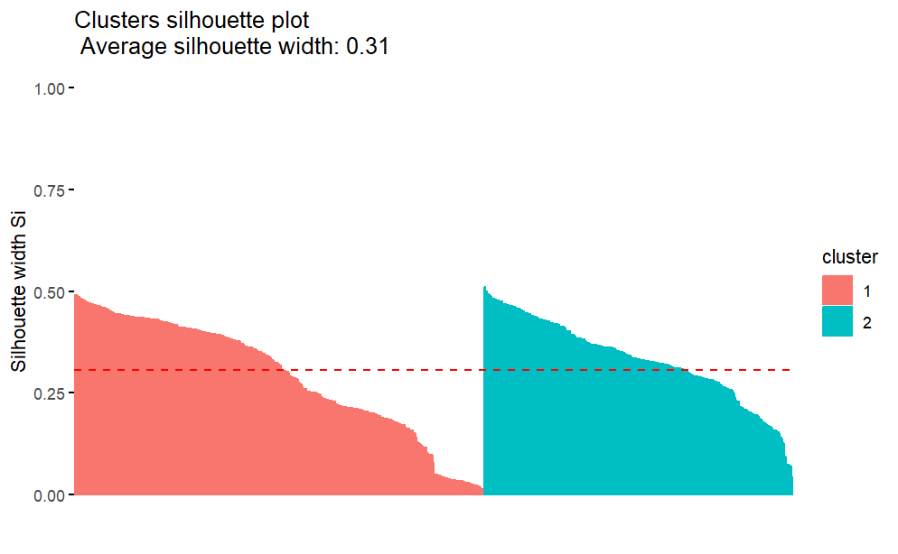

```r
#avg silhouette
library(cluster)
silh <- silhouette(km$cluster, dist(Employees))
rownames(silh) <- rownames(Employees)
fviz_silhouette(silh)
```

5. calculating the Total Within Cluster Sum of two clusters

```r
# Total sum of squares
km$tot.withinss
```

```
[1] 40750.1
```

6. calculating BCubed precision and recall of two clusters

```r
cluster_assignments <- c(km$cluster)
ground_truth_labels <- c(Sal)
data <- data.frame(cluster = cluster_assignments, label = ground_truth_labels)
# Function to calculate BCubed precision and recall
calculate_bcubed_metrics <- function(data) {
  n <- nrow(data)
  precision_sum <- 0
  recall_sum <- 0

  for (i in 1:n) {
    cluster <- data$cluster[i]
    label <- data$label[i]

    # Count the number of items from the same category within the same cluster
    same_category_same_cluster <- sum(data$label[data$cluster == cluster] == label)

    # Count the total number of items in the same cluster
    total_same_cluster <- sum(data$cluster == cluster)

    # Count the total number of items with the same category
    total_same_category <- sum(data$label == label)

    # Calculate precision and recall for the current item and add them to the sums
    precision_sum <- precision_sum + same_category_same_cluster / total_same_cluster
    recall_sum <- recall_sum + same_category_same_cluster / total_same_category
  }

  # Calculate average precision and recall
  precision <- precision_sum / n
  recall <- recall_sum / n

  return(list(precision = precision, recall = recall))
}

# Calculate BCubed precision and recall
metrics <- calculate_bcubed_metrics(data)
# Extract precision and recall from the metrics
precision <- metrics$precision
recall <- metrics$recall
# Print the results
cat("BCubed Precision:", precision, "\n")
```

```
BCubed Precision: 0.3349891
```

```r
cat("BCubed Recall:", recall, "\n")
```

```
BCubed Recall: 0.512721
```

#### 6.2.2 Second K-mean (k=3)

1. creating the 3 clusters

#### Cluster k=3

```r
#calculate k-mean k=3
km <- kmeans(Employees, centers= 3, iter.max = 100 , algorithm="Lloyd", nstart=100)
km
```

```
K-means clustering with 3 clusters of sizes 285, 270, 414

Cluster means:
  Education Department Job Status Location    Years Job Rate
1  2.494737   6.312281   1.754386 2.747368 4.569261 4.536842
2  2.225926   6.770370   1.781481 2.888889 4.216700 5.203704
3  2.362319  16.345411   1.690821 2.760870 4.321357 4.664251
  Permissions
1   10.266667
2    3.529630
3    7.028986

Clustering vector:
  [1] 3 3 1 3 3 3 3 1 2 3 2 2 3 1 3 2 3 2 1 1 3 3 3 1 3 3 3 3 1 3 2 1 2
 [34] 1 2 3 2 3 3 3 3 2 1 1 2 3 2 1 2 1 1 1 1 1 2 1 3 2 3 3 3 3 2 3 2 2
```

[output cut: 38 more lines]

2. visualizing the result in graphical format of three clusters

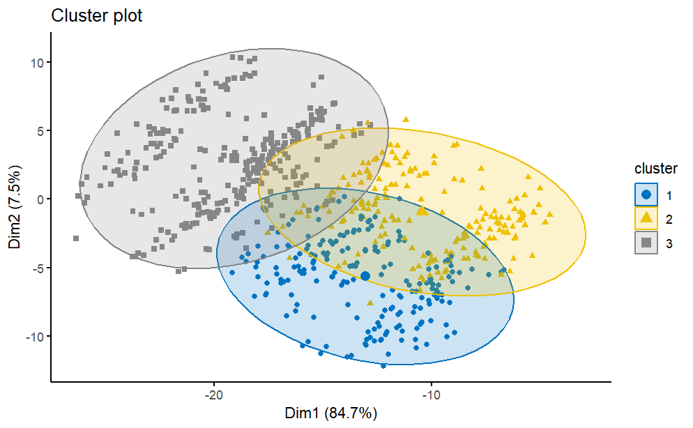

```r
# plot k-mean
fviz_cluster(list(data = Employees, cluster = km$cluster),
             ellipse.type = "norm", geom = "point", stand = FALSE,
             palette = "jco", ggtheme = theme_classic())
```

3. calculating the Average Silhouette Coefficient of three clusters

|  | cluster | size | ave.sil.width |
| --- | --- | --- | --- |
| 1 | 1 | 285 | 0.24 |
| 2 | 2 | 270 | 0.22 |
| 3 | 3 | 414 | 0.28 |

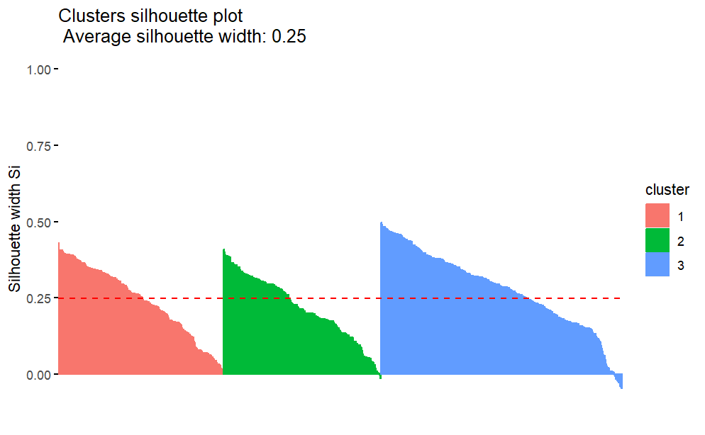

```r
#avg silhouette
library(cluster)
silh <- silhouette(km$cluster, dist(Employees))
rownames(silh) <- rownames(Employees)
fviz_silhouette(silh)
```

4. calculating the Total Within Cluster Sum of three clusters

```r
# Total sum of squares
km$tot.withinss
```

```
[1] 34529.21
```

5. calculating BCubed precision and recall of three clusters

```r
cluster_assignments <- c(km$cluster)
ground_truth_labels <- c(Sal)
data <- data.frame(cluster = cluster_assignments, label = ground_truth_labels)
# Function to calculate BCubed precision and recall
calculate_bcubed_metrics <- function(data) {
  n <- nrow(data)
  precision_sum <- 0
  recall_sum <- 0

  for (i in 1:n) {
    cluster <- data$cluster[i]
    label <- data$label[i]

    # Count the number of items from the same category within the same cluster
    same_category_same_cluster <- sum(data$label[data$cluster == cluster] == label)

    # Count the total number of items in the same cluster
    total_same_cluster <- sum(data$cluster == cluster)

    # Count the total number of items with the same category
    total_same_category <- sum(data$label == label)

    # Calculate precision and recall for the current item and add them to the sums
    precision_sum <- precision_sum + same_category_same_cluster / total_same_cluster
    recall_sum <- recall_sum + same_category_same_cluster / total_same_category
  }

  # Calculate average precision and recall
  precision <- precision_sum / n
  recall <- recall_sum / n

  return(list(precision = precision, recall = recall))
}

# Calculate BCubed precision and recall
metrics <- calculate_bcubed_metrics(data)
# Extract precision and recall from the metrics
precision <- metrics$precision
recall <- metrics$recall
# Print the results
cat("BCubed Precision:", precision, "\n")
```

```
BCubed Precision: 0.3352973
```

```r
cat("BCubed Recall:", recall, "\n")
```

```
BCubed Recall: 0.3487142
```

#### 6.2.3 Third K-mean (k=4)

1. creating the 4 clusters

#### Cluster k=4

```r
# calculate k-mean k=4
km <- kmeans(Employees, centers= 4, iter.max = 100 , algorithm="Lloyd", nstart=100)
km
```

```
K-means clustering with 4 clusters of sizes 286, 218, 222, 243

Cluster means:
  Education Department Job Status Location    Years Job Rate
1  2.216783   6.814685   1.797203 2.874126 4.286190 5.346154
2  2.252294  16.550459   1.683486 2.747706 4.422897 4.848624
3  2.531532  15.563063   1.743243 2.752252 4.286184 4.436937
4  2.481481   5.687243   1.699588 2.773663 4.478253 4.353909
  Permissions
1    3.856643
2    3.784404
3   10.423423
4   10.481481

Clustering vector:
```

[output cut: 40 more lines]

2.visualizing the result in graphical format of four clusters

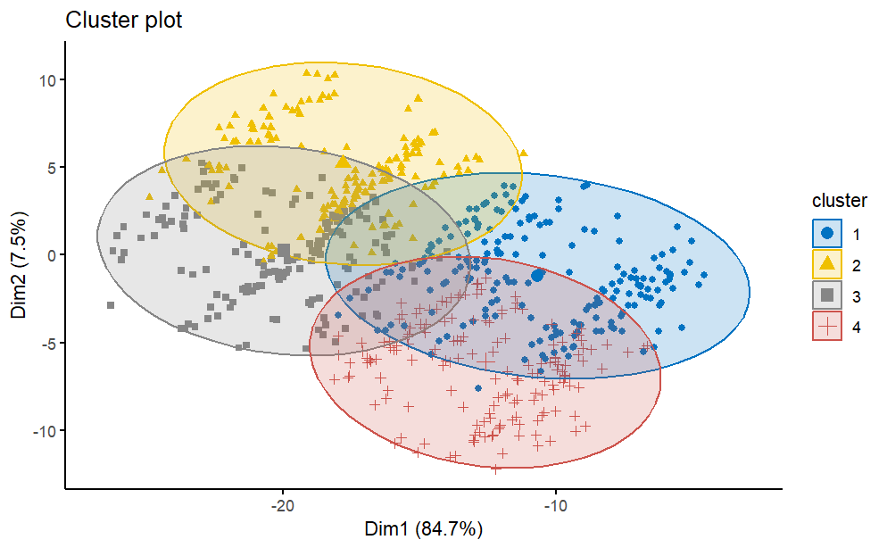

```r
# plot k-mean
fviz_cluster(list(data = Employees, cluster = km$cluster),
             ellipse.type = "norm", geom = "point", stand = FALSE,
             palette = "jco", ggtheme = theme_classic())
```

3. calculating the Average Silhouette Coefficient of four clusters

|  | cluster | size | ave.sil.width |
| --- | --- | --- | --- |
| 1 | 1 | 286 | 0.18 |
| 2 | 2 | 218 | 0.25 |
| 3 | 3 | 222 | 0.22 |
| 4 | 4 | 243 | 0.24 |

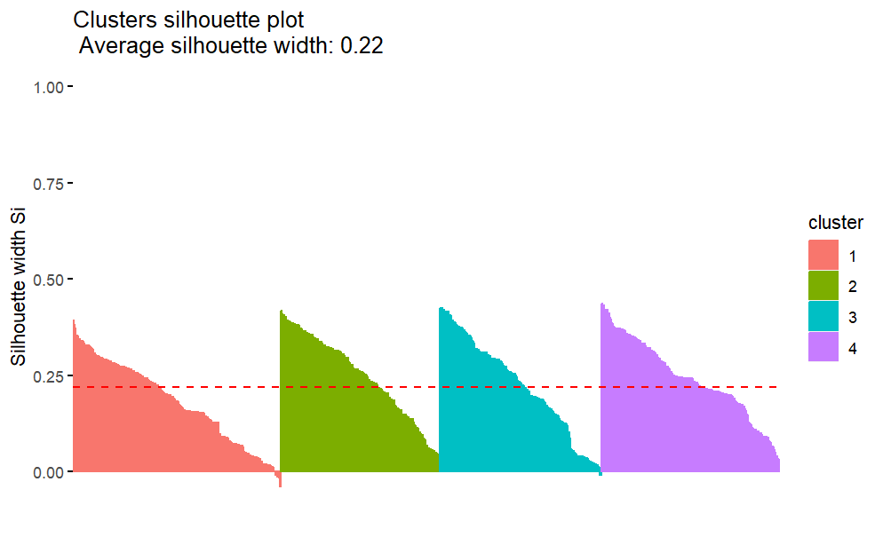

```r
# avg silhouette
library(cluster)
silh <- silhouette(km$cluster, dist(Employees))
rownames(silh) <- rownames(Employees)
fviz_silhouette(silh)
```

4. calculating the Total Within Cluster Sum of four clusters

```r
# Total sum of squares
km$tot.withinss
```

```
[1] 29822.08
```

5. calculating BCubed precision and recall of four clusters

```r
cluster_assignments <- c(km$cluster)
ground_truth_labels <- c(Sal)
data <- data.frame(cluster = cluster_assignments, label = ground_truth_labels)
# Function to calculate BCubed precision and recall
calculate_bcubed_metrics <- function(data) {
  n <- nrow(data)
  precision_sum <- 0
  recall_sum <- 0

  for (i in 1:n) {
    cluster <- data$cluster[i]
    label <- data$label[i]

    # Count the number of items from the same category within the same cluster
    same_category_same_cluster <- sum(data$label[data$cluster == cluster] == label)

    # Count the total number of items in the same cluster
    total_same_cluster <- sum(data$cluster == cluster)

    # Count the total number of items with the same category
    total_same_category <- sum(data$label == label)

    # Calculate precision and recall for the current item and add them to the sums
    precision_sum <- precision_sum + same_category_same_cluster / total_same_cluster
    recall_sum <- recall_sum + same_category_same_cluster / total_same_category
  }

  # Calculate average precision and recall
  precision <- precision_sum / n
  recall <- recall_sum / n

  return(list(precision = precision, recall = recall))
}

# Calculate BCubed precision and recall
metrics <- calculate_bcubed_metrics(data)
# Extract precision and recall from the metrics
precision <- metrics$precision
recall <- metrics$recall
# Print the results
cat("BCubed Precision:", precision, "\n")
```

```
BCubed Precision: 0.3362805
```

```r
cat("BCubed Recall:", recall, "\n")
```

```
BCubed Recall: 0.2555154
```

#### Plots Disscution:

Clusters silhouette plot: a higher average silhouette width is considered better, as it indicates that the clusters are well-defined and appropriately separated. Therefore, among the values 0.3, 0.25, and 0.22 of k=2, k=3 and k=4 respectively a average silhouette width of 0.3 is the best.

Cluster plot: Among k=2, k=3, and k=4, we observed overlapping in each of them, but the cluster with k=2 had the least overlapping, and the cluster with k=4 had the most overlapping.

#### 6.2.4 Using Elbow method

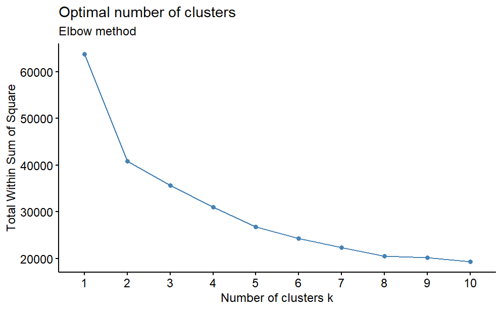

```r
##### Elbow with wss
fviz_nbclust(Employees, kmeans, method = "wss")+ labs(subtitle = "Elbow method")
```

#### 6.2.6 Comparison:

##### Table 5

|  | k=2 | k=3 | k=4 |
| --- | --- | --- | --- |
| Average Silhoutte width | 0.3 | 0.25 | 0.22 |
| total within-cluster sum of square | 40750.1 | 34529.21 | 29822.08 |
| BCubed precision | 0.3349891 | 0.3352973 | 0.3362805 |
| BCubed recall | 0.512721 | 0.3487142 | 0.2555154 |
| Visualization | all figure is shown above | all figure is shown above | all figure is shown above |

#### 6.2.7 Discussion:

Cluster with k-mean = 2 Average Silhoutte width was 0.3 indicating less space between objects of in a cluster and more space between objects in different clusters, total within-cluster sum of square was 40750.1, BCubed precision was 0.3349891 indicating objects of a cluster are correctly assigned to it, BCubed recall was 0.512721 indicating objects of the same category assigned to the same cluster.

Cluster with k-mean = 3 Average Silhoutte width was 0.25 indicating less space between objects of in a cluster and more space between objects in different clusters, total within-cluster sum of square was 34529.21, BCubed precision was 0.3352973 indicating objects of a cluster are correctly assigned to it, BCubed recall was 0.3487142 indicating objects of the same category assigned to the same cluster.

Cluster with k-mean = 4 Average Silhoutte width was 0.22 indicating less space between objects of in a cluster and more space between objects in different clusters, total within-cluster sum of square was 29822.08, BCubed precision was 0.3362805 indicating objects of a cluster are correctly assigned to it, BCubed recall was 0.2555154 indicating objects of the same category assigned to the same cluster.

### **7.0 Findings:**

In the beginning, we selected a dataset that represents the Sala’ry data to predict the probability of their Salary in a new jobs. To have efficient, correct, and the best possible accuracy results we applied several preprocessing techniques that improve the efficiency of the data. We applied several plotting methods such as boxplot, histogram and bar chart to illustrate the data so it can help us understand our data and make the appropriate preprocessing techniques. Based on the blots and other commands, we removed all null, missing, and outliers’ values that can badly affect the results. Also, we applied data transformation, so we normalized discretized, and incdeed some attributes to give them equal weight and to facilitate handling the data during data mining tasks. Consequently, we applied the data mining tasks which are classification and clustering.

#### Classification

For classification, we use the decision tree method to construct our model, we tried 3 different sizes of training and testing data to get the best result for construction and evaluation and different methods. So we concluded the following results: Information Gain:

|  | 70% training set 30% testing set: | 70% training set 30% testing set: | 70% training set 30% testing set: | 75% training set 25% testing set: | 75% training set 25% testing set: | 75% training set 25% testing set: | 65% training set 35% testing set: | 65% training set 35% testing set: | 65% training set 35% testing set: |
| --- | --- | --- | --- | --- | --- | --- | --- | --- | --- |
|  | IG | IG ratio | Gini Index | IG | IG ratio | Gini Index | IG | IG ratio | Gini Index |
| Accuracy | 84% | 85% | 84% | 83% | 85% | 83% | 81% | 82% | 81% |
| Precision | 94% | 98% | 94% | 93% | 87% | 93% | 88% | 87% | 88% |
| Sensitivity | 69% | 67% | 69% | 69% | 73% | 69% | 70% | 65% | 70% |
| Specificity | 95% | 99% | 95% | 94% | 91% | 94% | 90% | 92% | 90% |

#### Partition 1 (70% training set, 30% testing set):

IG algorithm: The accuracy is 84%, indicating that the model correctly predicted 84% of the instances in the testing set. The precision is 94%, meaning that almost all the instances predicted as positive by the model were actually positive. The sensitivity is 69%, indicating that the model correctly identified 69% of the positive instances. The specificity is 95%, meaning that the model correctly identified 95% of the negative instances.

IG Ratio algorithm: The accuracy is 85%, indicating that the model correctly predicted 85% of the instances in the testing set. The precision is 98%, meaning that about 98% instances predicted as positive by the model were actually positive. The sensitivity is 67%, indicating that the model correctly identified 67% of the positive instances. The specificity is 99%, meaning that the model correctly identified almost all the negative instances.

Gini Index algorithm: The accuracy is 84%, indicating that the model correctly predicted 84% of the instances in the testing set. The precision is 94%, meaning that 94% of the instances predicted as positive by the model were actually positive. The sensitivity is 69%, indicating that the model correctly identified 69% of the positive instances. The specificity is 95%, meaning that the model correctly identified 95% of the negative instances.

When we choose the best algorithm, we go towards the algorithm the highest accuracy. The IG Ratio algorithm achieved an accuracy of 85%, which is the higher than IG algorithm and Gini Index algorithm in this partition.

#### Partition 2 (75% training set, 25% testing set):

IG algorithm: The accuracy is 83%, indicating that the model correctly predicted 83% of the instances in the testing set. The precision is 93%, meaning that 93% of the instances predicted as positive by the model were actually positive. The sensitivity is 69%, indicating that the model correctly identified 69% of the positive instances. The specificity is 94%, meaning that the model correctly identified 94% of the negative instances.

IG Ratio algorithm: The accuracy is 85%, indicating that the model correctly predicted 85% of the instances in the testing set. The precision is 87%, meaning that only 87% of the instances predicted as positive by the model were actually positive. The sensitivity is 73%, indicating that the model correctly identified 73% of the positive instances. The specificity is 91%, meaning that the model correctly identified a lot of the negative instances.

Gini Index algorithm: The accuracy is 83%, indicating that the model correctly predicted 83% of the instances in the testing set. The precision is 93%, meaning that 93% of the instances predicted as positive by the model were actually positive. The sensitivity is 69%, indicating that the model correctly identified 69% of the positive instances. The specificity is 94%, meaning that the model correctly identified 94% of the negative instances.

When we choose the best algorithm, we go towards the algorithm the highest accuracy. The IG Ratio algorithm achieved an accuracy of 85%, which is the higher than IG algorithm and Gini Index algorithm in this partition.

#### Partition 3 (65% training set, 35% testing set):

IG algorithm: The accuracy is 81%, indicating that the model correctly predicted 81% of the instances in the testing set. The precision is 88%, meaning that 88% of the instances predicted as positive by the model were actually positive. The sensitivity is 70%, indicating that the model correctly identified 70% of the positive instances. The specificity is 90%, meaning that the model correctly identified 90% of the negative instances.

IG Ratio algorithm: The accuracy is 82%, indicating that the model correctly predicted 82% of the instances in the testing set. The precision is 87%, meaning that a lot of the instances predicted as positive by the model were actually positive. The sensitivity is 65%, indicating that the model correctly identified 65% of the positive instances. The specificity is 92%, meaning that the model correctly identified 92% of the negative instances.

Gini Index algorithm: The accuracy is 81%, indicating that the model correctly predicted 81% of the instances in the testing set. The precision is 88%, meaning that 88% of the instances predicted as positive by the model were actually positive. The sensitivity is 70%, indicating that the model correctly identified 70% of the positive instances. The specificity is 90%, meaning that the model correctly identified 90% of the negative instances.

When we choose the best algorithm, we go towards the algorithm the highest accuracy. The IG Ratio algorithm achieved an accuracy of 82%, which is the higher than IG algorithm and Gini Index algorithm in this partition.

*Overall Best Algorithm (based on accuracy):*

The IG Ratio algorithm achieved the highest accuracy across all partitions. While the accuracy of the IG Ratio algorithm varied slightly in each partition (85% in Partition 1, 85% in Partition 2, and 82% in Partition 3), it consistently outperformed the other algorithms in terms of accuracy.

**Best Decision Tree:**

**Several findings can be drawn from the decision tree analysis:**

#### Clustering

|  | k=2 | k=3 | k=4 |
| --- | --- | --- | --- |
| Average Silhoutte width | 0.3 | 0.25 | 0.22 |
| total within-cluster sum of square | 40750.1 | 34529.21 | 29822.08 |
| BCubed precision | 0.3349891 | 0.3352973 | 0.3362805 |
| BCubed recall | 0.512721 | 0.3487142 | 0.2555154 |
| Visualization | all figure is shown above | all figure is shown above | all figure is shown above |

**Discussion:**

#### Cluster with k-mean = 2

Average Silhoutte width was 0.3 indicating less space between objects of in a cluster and more space between objects in different clusters, total within-cluster sum of square was 40750.1, BCubed precision was 0.3349891 indicating objects of a cluster are correctly assigned to it, BCubed recall was 0.512721 indicating objects of the same category assigned to the same cluster.

#### Cluster with k-mean = 3

Average Silhoutte width was 0.25 indicating less space between objects of in a cluster and more space between objects in different clusters, total within-cluster sum of square was 34529.21, BCubed precision was 0.3352973 indicating objects of a cluster are correctly assigned to it, BCubed recall was 0.3487142 indicating objects of the same category assigned to the same cluster.

#### Cluster with k-mean = 4

Average Silhoutte width was 0.22 indicating less space between objects of in a cluster and more space between objects in different clusters, total within-cluster sum of square was 29822.08, BCubed precision was 0.3362805 indicating objects of a cluster are correctly assigned to it, BCubed recall was 0.2555154 indicating objects of the same category assigned to the same cluster.

**findings:**

From the results of the methods implemented on “Employees” data set we obtained the following: the model with the number of clusters k=2 had average silhouette width=0.3 it is the best result since the model with the number of clusters k=3 and 4 had average silhouette width=0.25 and 0.22 respectively this means that the the model with the number of clusters k=2 has the highest average silhouette result, this value indicates that that objects within the same cluster are close to each other and as far as possible to the objects in the other cluster.

For total within cluster sum results of model with the number of clusters k=2 we had a result with the value of 40750.1 this value represents the distances between each data point in a cluster and the centroid of that cluster, which is considered relatively large compared to the other two models’ results, for model with the number of clusters k=3 and 4 we had the results 34529.21 and 29822.08 respectively, in my opinion as the number of clusters (k) increases, the total within cluster sum generally decreases because the data points are closer to their cluster centroids, more specifically, with more clusters, each cluster tends to have fewer data points, and these data points are typically closer to their cluster centroid. This leads to a decrease in the overall WCSS, indicating that the data points are more tightly clustered around their respective centroids.

BCubed precision and recall results showed that model with the number of clusters k=2 has the least precision with a relatively small difference compared to other k-means, precision value is 0.3349891 and the highest recall with the value 0.512721, the model with the number of clusters k=3 and 4 had precision values of 0.3352973 and 0.3362805 respectively and the model with the number of clusters k=3 snd 4 had recall values of 0.3487142 and 0.2555154 respectively, A higher precision indicates that, within a cluster, the data points are more homogeneous and accurately assigned to the same group and higher recall implies that the clustering algorithm is effective in identifying and grouping together all instances of a specific category.

Finally, both models are helpful for predicting Salaries and helped us to reach our goal which is helping people to take in consideration if they having a good salary at their current job or the new job also!, but Since our data contains a class label “Salary” This makes Supervised Learning models(classification) more accurate and suitable to apply than unsupervised learning model(clustering), as the expected output is known beforehand this way we makes use of the class label attribute. Also, when comparing the highest accuracy when applying the Classification Model: Accuracy = 85% with the highest accuracy when applying the Clustering Model: Precision = 33%, we notice that the accuracy rate in the Classification Model is higher, which shows that using Classification to predict Salary is the best and most accurate.

### 8.0 Reference

[1] QUSAY AL-BTOUSH, Employees, Kaggle, 2021,Available: https://www.kaggle.com/datasets/qusaybtoush1990/employes. Accessed on: September 10, 2023

[2] [1] S.-A. N. Alexandropoulos, S. B. Kotsiantis, and M. N. Vrahatis, “Data preprocessing in predictive data mining,” *The Knowledge Engineering Review*, vol. 34, no. e1, pp. 1-33, 2019. DOI: 10.1017/S026988891800036X.

[3] RDocumentation, “Information Gain - RDocumentation,” RDocumentation, Available: https://www.rdocumentation.org/packages/FSelectorRcpp/versions/0.3.11/topics/information_gain, Accessed on: November 8, 2023.

[4] RDocumentation, “rpart - RDocumentation,” RDocumentation, Available: https://www.rdocumentation.org/packages/rpart/versions/4.1.21/topics/rpart, Accessed on: November 10, 2023.

[5] RDocumentation, “C5.0 - RDocumentation,” RDocumentation, Available: <https://www.rdocumentation.org/packages/C50/versions/0.1.8/topics/C5.0.default,) Accessed on: November 10, 2023.

[6] G. K. Roussel, M. Chessel, and S. J. Champely, “Factoextra: Extract and Visualize the Results of Multivariate Data Analyses,” R package version 1.0.7, Extract and Visualize the Results of Multivariate Data Analyses, 2021. [Online]. Available: https://cran.r-project.org/package=factoextra. Accessed: November 29, 2023.